# OPENCLASSROOMS - PROJET 7

# EFFECTUEZ UNE PRÉDICTION DE REVENUS

## Sommaire

###### Un code de couleur à été attribué aux différentes missions à titre de repère

### Mission 1: Présentation des données

#### I.Nettoyage des données

- I.1.Tableau de base
- I.2.Ajustement des types
- I.3.Valeurs aberrantes
- I.4.Traitement des valeurs manquantes

#### II.Récoltes de données supplémentaires

- II.1.Nombre d'habitants de chaque pays présents dans la base
- II.2.Calcul des indices de Gini

#### III.Résumé des données utilisées

- III.1.Nombre de pays observés et variables étudiées
- III.2.Pourcentage de la population mondiale couverte par l'analyse

### Mission 2: Analyse des distributions de revenus

#### I.Sélection diversifiée des pays à analyser

- I.1.Classification hierarchique ascendante et dendrogramme
- I.2.Sélection des pays pour l'analyse

#### II.Distributions de revenus et indices de Gini des pays sélectionnés

- II.1.Représentation graphique des distributions de revenus
- II.2.Courbes de Lorenz
- II.3.Évolution de l'indice de Gini au fil des ans
- II.4.Classement des pays selon l'indice de Gini

### Mission 3: Génération des individus

#### I.Coefficients d'élasticité

- I.1.Ajout des coefficients d'élasticité donnés par la World Bank
- I.2.Ajout des coefficients d'élasticité restants

#### II.Distributions conditionnelles des revenus

- II.1.Tableau des distributions conditionnelles des classes de revenu selon une élasticité donnée
- II.2.Fonctions génératrices des distributivités

#### III.Génération des classes de revenu

- III.1.Ajustement des données de base
- III.2.Création de l'échantillon
- III.3.Ajout des classes de revenu des parents

### Mission 4: Étude des revenus

#### I.Préliminaires des analyses à venir

- I.1.Récapitulatif et niveau de test
- I.2.Ajout des variables logarithmiques
- I.3.Fonctions utilitaires sur les résidus des modélisations
- I.4.Fonctions utilitaires sur les régression linéaires multiples et leurs variables explicatives

#### II.Revenu de l'individu selon le pays d'origine

- II.1.Aperçu de l'influence du pays d'origine sur le revenu
- II.2.Modélisation et évaluation du modèle
- II.3.Test de Fisher
- II.4.Analyse des résidus
- II.5.Reprise de l'ANOVA en passant les revenus des individus au logarithme

#### III.Régressions linéaires multiples sur les revenus des individus

- III.1.Revenu moyen du pays et indice de Gini - Premier modèle selon les données actuelles
- III.2.Revenu moyen du pays et indice de Gini - Second modèle selon les données exprimées en logarithme
- III.3.Comparaison des deux modèles: Coefficient de détermination et analyse des résidus
- III.4.Décomposition de la variance expliquée par le second modèle
- III.5.Ajout de la classe de revenu des parents dans la modélisation
- III.6.Ajout des variables restantes

#### IV.Bilan sur la variance des revenus

- IV.1.Explication de la variance des revenus selon nos résultats
- IV.2.Conclusion
- IV.3.Bonus: Proposition d'un algorithme de prédiction

### Nous importons dans un premier temps l'ensemble des librairies nécessaires pour l'ensemble du projet.

```python
import pandas as pd
import numpy as np
import random

from IPython.display import Image

import matplotlib.pyplot as plt
from matplotlib.pylab import arange, plot
from matplotlib.pyplot import figure

from sklearn import preprocessing
from sklearn.preprocessing import StandardScaler
sc = StandardScaler()
from functions import*

import scipy
import scipy.stats as st
from scipy.cluster.hierarchy import dendrogram
from scipy.cluster.hierarchy import linkage, fcluster
from scipy.stats import t, shapiro
from scipy.stats import ks_2samp

from collections import Counter

import warnings
warnings.filterwarnings('ignore')

import statsmodels.formula.api as smf
from statsmodels.formula.api import ols
import statsmodels.api as sm
from statsmodels.stats.outliers_influence import variance_inflation_factor

#Ci-dessous sont importées les fonctions données par l'énoncé du projet 7 pour la mission 3, enregistrés dans un dossier .py:
from codes_mission_3 import*
```

# Mission 1: Présentation des données

# I. Nettoyage des données

### I.1. Tableau de base

#### Invoquons notre DataFrame de base - que nous appellerons "df" - issu de la World Income Distribution qui contient les variables suivantes:

- [country_code]: Le code ISO d'un pays donné.
- [year_survey]: L'année où ont été relevées les données.
- [quantile]: Pour chaque pays, on dispose de 100 quantiles, chacun représentant 1% de la population. Ils sont numérotés de 1 à 100 où quantile numéro 1 représente la moyenne des revenus la plus faible et le quantile numéro 100 la moyenne la plus élevée. Cette colonne indique alors le numéro du quantile en question.
- [nb_quantile]: Renvoie le nombre de quantiles pour un pays donné. En l'occurence, ce nombre est toujours égal à 100.
- [income]: La moyenne des revenus pour un quantile donné dans un pays donné au cours de l'année en question, converti en dollards.
- [gdpppp]: Le PIB par habitant à parité de pouvoir d'achats.

```python
df=pd.read_csv("data/projet_7/data_p7.csv")

df.rename(columns={"country": "country_code",
                   "year_survey": "year"}, inplace=True)

df
```

|  | country_code | year | quantile | nb_quantiles | income | gdpppp |
| --- | --- | --- | --- | --- | --- | --- |
| 0 | ALB | 2008 | 1 | 100 | 728,89795 | 7297 |
| 1 | ALB | 2008 | 2 | 100 | 916,66235 | 7297 |
| 2 | ALB | 2008 | 3 | 100 | 1010,916 | 7297 |
| 3 | ALB | 2008 | 4 | 100 | 1086,9078 | 7297 |
| 4 | ALB | 2008 | 5 | 100 | 1132,6997 | 7297 |
| ... | ... | ... | ... | ... | ... | ... |
| 11594 | COD | 2008 | 96 | 100 | 810,6233 | 303,19305 |
| 11595 | COD | 2008 | 97 | 100 | 911,7834 | 303,19305 |
| 11596 | COD | 2008 | 98 | 100 | 1057,8074 | 303,19305 |
| 11597 | COD | 2008 | 99 | 100 | 1286,6029 | 303,19305 |
| 11598 | COD | 2008 | 100 | 100 | 2243,1226 | 303,19305 |

11599 rows × 6 columns

### I.2. Ajustement des types

Examinons dans un premiers temps le type de chaque colonne de notre base.

```python
print(df.info())
```

```
<class 'pandas.core.frame.DataFrame'>
RangeIndex: 11599 entries, 0 to 11598
Data columns (total 6 columns):
country_code    11599 non-null object
year            11599 non-null int64
quantile        11599 non-null int64
nb_quantiles    11599 non-null int64
income          11599 non-null object
gdpppp          11399 non-null object
dtypes: int64(3), object(3)
memory usage: 543.8+ KB
None
```

```python
#On applique ensuite cette fonction aux deux colonnes concernées de "df":
df["income"]=[float(str(i).replace(",",".")) for i in df.income]
df["gdpppp"]=[float(str(i).replace(",",".")) for i in df.gdpppp]

df[["income", "gdpppp"]].info()
```

```
<class 'pandas.core.frame.DataFrame'>
RangeIndex: 11599 entries, 0 to 11598
Data columns (total 2 columns):
income    11599 non-null float64
gdpppp    11399 non-null float64
dtypes: float64(2)
memory usage: 181.4 KB
```

### I.3. Valeurs aberrantes

Constatons que le PIB par habitant des Îles Fidji paraissait anormalement élevé par rapport aux autres pays.

```python
print("PIB/hbts de la France:", df.loc[df["country_code"]=="FRA", "gdpppp"].unique()[0])
print("PIB/hbts du Luxembourg:", df.loc[df["country_code"]=="LUX", "gdpppp"].unique()[0])
print("PIB/hbts des Îles Fidji:", df.loc[df["country_code"]=="FJI", "gdpppp"].unique()[0])
```

```
PIB/hbts de la France: 30357.0
PIB/hbts du Luxembourg: 73127.0
PIB/hbts des Îles Fidji: 4300332.0
```

```python
df.loc[df["country_code"]=="FJI", "gdpppp"]=7777.7
print("PIB/hbts corrigé des Îles Fidji:", df.loc[df["country_code"]=="FJI", "gdpppp"].unique()[0])
```

```
PIB/hbts corrigé des Îles Fidji: 7777.7
```

### I.4. Traitement des valeurs manquantes

Intéressons-nous au nombre de pays que contient df et à ses dimensions.

```python
print("Nombre de lignes de df: %d" %len(df))
print("Nombre de pays contenu dans df: %s" %len(df["country_code"].unique()))
```

```
Nombre de lignes de df: 11599
Nombre de pays contenu dans df: 116
```

Chaque pays est supposé être représenté par 100 quantiles (centiles). Donc les lignes de notre tableau sont censée être exactement au nombre de 100 fois le nombre de pays présents. Les valeurs données ci-dessus nous indiquent donc qu'un centile est absent pour un pays donné. Nous allons donc l'identifier ce pays ainsi que son quantile manquant et ajouter la ligne manquante à df.

```python
#Identification du pays concerné:
for cc in df["country_code"].unique():
    if len(df.loc[df["country_code"]==cc, "quantile"])<100:
        country=cc
        print("Code ISO du pays concerné:", cc)

#Identification du quantile manquant:
for i in range(1, 101):
    if i not in df.loc[df["country_code"]==country, "quantile"].values:
        print("Il lui manque le %d ème quantile!" %i)
```

```
Code ISO du pays concerné: LTU
Il lui manque le 41 ème quantile!
```

Il s'agit donc de la Lituanie, et le 41ème quantile est donc absent. Nous allons donc nous baser sur les revenus moyens des centiles 40 et 42 de la Lituanie puis prendre leur moyenne pour estimer le revenu moyen du centile 41. Puis nous ajoutons cette nouvelle ligne à df.

```python
ltu=df.loc[df["country_code"]=="LTU"]
rm=0
for i in [40, 42]: rm+=ltu.loc[ltu["quantile"]==i, "income"].values[0]
rm/=2
rm
df.loc[len(df)]=["LTU", 2008, 41, 100, rm, 17571.0]

df=df.sort_values(by=["country_code", "quantile"])
df=df.reset_index(drop=True)

#On peut observer que le nombre de lignes de df est bien passé de 11599 à 1600:
df
```

|  | country_code | year | quantile | nb_quantiles | income | gdpppp |
| --- | --- | --- | --- | --- | --- | --- |
| 0 | ALB | 2008 | 1 | 100 | 728.89795 | 7297.0 |
| 1 | ALB | 2008 | 2 | 100 | 916.66235 | 7297.0 |
| 2 | ALB | 2008 | 3 | 100 | 1010.91600 | 7297.0 |
| 3 | ALB | 2008 | 4 | 100 | 1086.90780 | 7297.0 |
| 4 | ALB | 2008 | 5 | 100 | 1132.69970 | 7297.0 |
| ... | ... | ... | ... | ... | ... | ... |
| 11595 | ZAF | 2008 | 96 | 100 | 24553.56800 | 9602.0 |
| 11596 | ZAF | 2008 | 97 | 100 | 28858.03100 | 9602.0 |
| 11597 | ZAF | 2008 | 98 | 100 | 35750.29000 | 9602.0 |
| 11598 | ZAF | 2008 | 99 | 100 | 46297.31600 | 9602.0 |
| 11599 | ZAF | 2008 | 100 | 100 | 82408.55000 | 9602.0 |

11600 rows × 6 columns

Repérons maintenant les éventuelles colonnes présentant au moins une valeur manquante.

```python
df.isnull().sum()
```

```
country_code      0
year              0
quantile          0
nb_quantiles      0
income            0
gdpppp          200
dtype: int64
```

On observe une 200 valeurs manquantes dans la colonne "gdpppp". Repérons alors les pays concernés.

```python
[i for i in df.loc[df["gdpppp"].isnull()==True]["country_code"].unique()]
```

```
['PSE', 'XKX']
```

On remarque alors les deux valeurs manquantes du tableau: les PIB par habitant du Kosovo (XKX) et de la Palestine (PSE). Selon le site Perspective Mode (https://perspective.usherbrooke.ca/), le PIB par habitant du Kosovo était de 7249 dollars PPA en 2008, et selon la FAO stats, celui de la Palestine de 3816,2 dollars PPA en 2009. Ajoutons alors ces deux valeurs au DataFrame.

```python
df.loc[df["country_code"]=="XKX"]=df.loc[df["country_code"]=="XKX"].fillna(7249)
df.loc[df["country_code"]=="PSE"]=df.loc[df["country_code"]=="PSE"].fillna(3816.20)
df.loc[(df["country_code"]=="XKX") | (df["country_code"]=="PSE")]

#On peut vérifier que l'on en a terminé avec les valeurs manquantes dans le tableau de base:
df.isnull().sum()
```

```
country_code    0
year            0
quantile        0
nb_quantiles    0
income          0
gdpppp          0
dtype: int64
```

# II. Récoltes de données supplémentaires

### II.1. Nombre d'habitants de chaque pays présents dans la base

Récupérons dans un premier temps le nombre d'habitants de chaque pays présents dans notre DataFrame pour l'année en question. Ici, nous avons récupérer sur la faostats la liste des populations de chaque pays de 2004 à 2011 (années où s'étendent nos données de base). Nous appellerons "pop" ce DataFrame. Nous en profiterons pour récupérer également le nom des pays indiqués jusqu'ici par leur code ISO.

```python
pop=pd.read_csv("data/projet_7/gini/population.csv")

pop=pop.drop(columns=["Code Domaine", "Domaine", "Code Élément", "Élément", "Produit", "Code Produit",
                      "Symbole", "Description du Symbole", "Code année", "Unité"])

pop=pop.rename(columns={"Code zone": "country_code", "Zone": "country", "Année": "year",
                        "Valeur": "population"})

pop["population"]=1000*pop.population
pop.loc[pop["country"]=="Royaume-Uni de Grande-Bretagne et d'Irlande du Nord", "country"]="Royaume-Uni"

df=pd.merge(df, pop, how="left")
df=df.reindex(columns=["country_code", "country", "year", "quantile", "nb_quantiles",
                       "income", "gdpppp", "population"])

df.tail(4)
```

|  | country_code | country | year | quantile | nb_quantiles | income | gdpppp | population |
| --- | --- | --- | --- | --- | --- | --- | --- | --- |
| 11596 | ZAF | Afrique du Sud | 2008 | 97 | 100 | 28858.031 | 9602.0 | 50267000.0 |
| 11597 | ZAF | Afrique du Sud | 2008 | 98 | 100 | 35750.290 | 9602.0 | 50267000.0 |
| 11598 | ZAF | Afrique du Sud | 2008 | 99 | 100 | 46297.316 | 9602.0 | 50267000.0 |
| 11599 | ZAF | Afrique du Sud | 2008 | 100 | 100 | 82408.550 | 9602.0 | 50267000.0 |

On récupère également les données manquantes à la liste trouvée sur la faostats, à savoir les populations et noms des pays ci-dessous, d'après le site: http://datatopics.worldbank.org/world-development-indicators/.

```python
df.loc[df["country_code"]=="BTN", "country"]="Bhoutan"
df.loc[df["country_code"]=="XKX", "country"]="Kosovo"
df.loc[df["country_code"]=="SDN", "country"]="Soudan"
df.loc[df["country_code"]=="SYR", "country"]="Syrie"
df.loc[df["country_code"]=="PSE", "country"]="Palestine"
df.loc[df["country_code"]=="COD", "country"]="République du Congo"


df.loc[df["country_code"]=="BTN", "population"]=664876
df.loc[df["country_code"]=="XKX", "population"]=1747000
df.loc[df["country_code"]=="SDN", "population"]=33780000
df.loc[df["country_code"]=="SYR", "population"]=17830000
df.loc[df["country_code"]=="PSE", "population"]=3689000
df.loc[df["country_code"]=="COD", "population"]=60410000

df
```

|  | country_code | country | year | quantile | nb_quantiles | income | gdpppp | population |
| --- | --- | --- | --- | --- | --- | --- | --- | --- |
| 0 | ALB | Albanie | 2008 | 1 | 100 | 728.89795 | 7297.0 | 3157000.0 |
| 1 | ALB | Albanie | 2008 | 2 | 100 | 916.66235 | 7297.0 | 3157000.0 |
| 2 | ALB | Albanie | 2008 | 3 | 100 | 1010.91600 | 7297.0 | 3157000.0 |
| 3 | ALB | Albanie | 2008 | 4 | 100 | 1086.90780 | 7297.0 | 3157000.0 |
| 4 | ALB | Albanie | 2008 | 5 | 100 | 1132.69970 | 7297.0 | 3157000.0 |
| ... | ... | ... | ... | ... | ... | ... | ... | ... |
| 11595 | ZAF | Afrique du Sud | 2008 | 96 | 100 | 24553.56800 | 9602.0 | 50267000.0 |
| 11596 | ZAF | Afrique du Sud | 2008 | 97 | 100 | 28858.03100 | 9602.0 | 50267000.0 |
| 11597 | ZAF | Afrique du Sud | 2008 | 98 | 100 | 35750.29000 | 9602.0 | 50267000.0 |
| 11598 | ZAF | Afrique du Sud | 2008 | 99 | 100 | 46297.31600 | 9602.0 | 50267000.0 |
| 11599 | ZAF | Afrique du Sud | 2008 | 100 | 100 | 82408.55000 | 9602.0 | 50267000.0 |

11600 rows × 8 columns

### II.2. Calcul des indices de Gini

Nous allons rapportés la population de chaque pays présents dans la base à 100 habitants, chacun représenté par un centile. Et nous considérerons le revenu moyen attribué à un centile dans la colonne "income" comme le revenu de ce centile pour calculer l'indice de Gini de chaque pays présents dans "df", puis nous ajouterons ces indices à celui-ci.

```python
#On crée ici la liste P de chaque pays présent dans notre base:
P=df.country_code.unique()

#On crée maintenant la liste G qui contiendra l'indice de Gini de chaque pays présent dans P:
G=[]
for i in P:
    revenus = df.loc[df["country_code"]==i].income.values
    lorenz = np.append([0], np.cumsum(revenus)/sum(revenus))
    gini=2*(0.5-lorenz.sum()/len(revenus))
    G=np.append(G, gini)

#Créons le DataFrame contenant chaque pays présents dans notre base accompagné de son indice de Gini:
gini_list=pd.DataFrame({"country_code": P,
                        "gini": G})

#Puis on l'ajoute à "df" par une jointure gauche:
df=pd.merge(df, gini_list, how="left")
df
```

|  | country_code | country | year | quantile | nb_quantiles | income | gdpppp | population | gini |
| --- | --- | --- | --- | --- | --- | --- | --- | --- | --- |
| 0 | ALB | Albanie | 2008 | 1 | 100 | 728.89795 | 7297.0 | 3157000.0 | 0.294624 |
| 1 | ALB | Albanie | 2008 | 2 | 100 | 916.66235 | 7297.0 | 3157000.0 | 0.294624 |
| 2 | ALB | Albanie | 2008 | 3 | 100 | 1010.91600 | 7297.0 | 3157000.0 | 0.294624 |
| 3 | ALB | Albanie | 2008 | 4 | 100 | 1086.90780 | 7297.0 | 3157000.0 | 0.294624 |
| 4 | ALB | Albanie | 2008 | 5 | 100 | 1132.69970 | 7297.0 | 3157000.0 | 0.294624 |
| ... | ... | ... | ... | ... | ... | ... | ... | ... | ... |
| 11595 | ZAF | Afrique du Sud | 2008 | 96 | 100 | 24553.56800 | 9602.0 | 50267000.0 | 0.659779 |
| 11596 | ZAF | Afrique du Sud | 2008 | 97 | 100 | 28858.03100 | 9602.0 | 50267000.0 | 0.659779 |
| 11597 | ZAF | Afrique du Sud | 2008 | 98 | 100 | 35750.29000 | 9602.0 | 50267000.0 | 0.659779 |
| 11598 | ZAF | Afrique du Sud | 2008 | 99 | 100 | 46297.31600 | 9602.0 | 50267000.0 | 0.659779 |
| 11599 | ZAF | Afrique du Sud | 2008 | 100 | 100 | 82408.55000 | 9602.0 | 50267000.0 | 0.659779 |

11600 rows × 9 columns

# III.Résumé des données utilisées

### III.1. Nombre de pays observés et variables étudiées

• Nous avons alors une liste de **116 pays** dont les données sont relevées chacun pour une seule année donnée entre 2004 et 2011 incluses, exceptée 2005.

• La colonne "gdpppp" (Gross Domestic Product based on Purchasing Power Parity) représente le PIB à parité de pouvoir d'achat calculé divisé par le nombre d'habitants d'un pays donné.

• La population de chaque pays est représentée par des **centiles**, nous avons divisé par 100 chaque population, et regroupé les habitants selon leur revenu. Plus le revenu est élevé, plus l'indice du quantile dans lequel se situe un habitant sera proche de 100, puis nous avons donné le revenu moyen des habitants de chaque quantile dans la colonne "income".

• Échantillonner une population en utilisant des quantiles est, selon moi, une bonne méthode car cela permet de minimiser le besoin en récoltes des données, et nous permet d'éviter les cas particuliers. Cela nous a permis de donner un indice de Gini à chaque pays dans la colonne "gini" en ne considérants que les revenus moyens des centiles donnés.

### III.2. Pourcentage de la population mondiale couverte par l'analyse

La plupart des données que nous traitons ayant été relevées en 2008. Considérons alors la population mondiale comme la population mondiale de 2008 + les valeurs ajoutées dans la partie précédente par la World Bank, et calculons le pourcentage de la population mondiale couverte par notre analyse.

```python
XX=["BTN", "XKX", "SDN", "SYR", "PSE", "COD"]
eps=df.loc[df["country_code"].isin(XX)==True, "population"].unique().sum()

per=round(100*sum(df.drop_duplicates(["country_code"]).population)/(sum(pop.loc[pop["year"]==2008].population)+eps), 2)
print("L'analyse couvre donc environ", per, "% de la population mondiale.")
```

```
L'analyse couvre donc environ 76.71 % de la population mondiale.
```

# Mission 2: Analyse des distributions de revenus

# I. Sélection diversifiée des pays à analyser

### I.1. Classification hierarchique ascendante et dendrogramme

Il nous faut sélectionner entre 5 à 10 pays de notre base de données pour montrer la diversité mondiale en terme de distribution de revenus. Pour les sélectionner de manière la plus objective possible, une classification hiérarchique ascendante non-supervisée de ces pays sur df selon les variables "income" et "gdpppp", en tracerons un dendrogramme pour déterminer le nombre de groupes distincts raisonnables à étudier, et sélectionnerons un pays donné par groupe obtenu.

```python
var=df[["country_code", "income", "gdpppp"]]
var=pd.DataFrame(var.groupby("country_code").mean())

X=var.values
std_scaler = preprocessing.StandardScaler().fit(X)
X_scaled = std_scaler.transform(X)

df_scaled=pd.DataFrame(X_scaled,
                  index=var.index,
                  columns=var.columns)

df_scaled
```

| country_code | income | gdpppp |
| --- | --- | --- |
| ALB | -0.463541 | -0.393032 |
| ARG | -0.033358 | 0.059328 |
| ARM | -0.669573 | -0.521797 |
| AUT | 1.593512 | 1.813852 |
| AZE | -0.559648 | -0.331628 |
| ... | ... | ... |
| VEN | -0.437559 | -0.052483 |
| VNM | -0.707360 | -0.753437 |
| XKX | -0.586963 | -0.396698 |
| YEM | -0.757892 | -0.780474 |
| ZAF | -0.068034 | -0.216991 |

116 rows × 2 columns

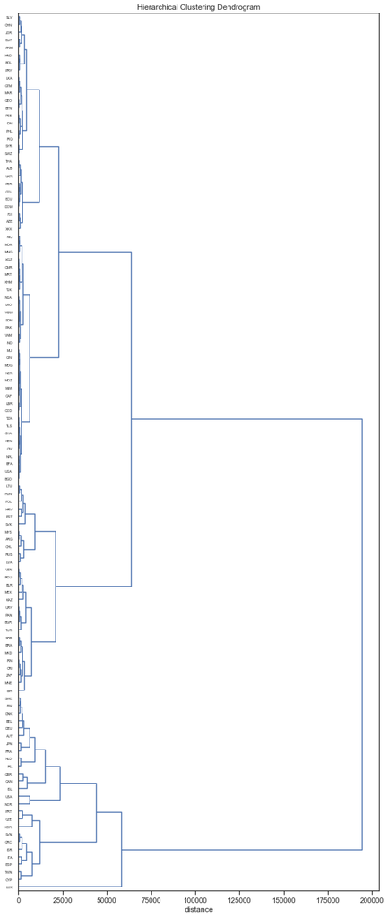

```python
#Préparation des données pour le clustering:
names = df_scaled.index

#Clustering hiérarchique:
Z = linkage(X, 'ward')

plot_dendrogram(Z, names)
plt.show()
```

En analysant le dendrogramme, il nous laisse suggérer que réaliser 8 clusters nous permettrait une bonne répartition des diversités.

```python
Y = df_scaled.values
names = df_scaled.index
Z = linkage(Y, 'ward')

#On ajoute la colonne "cluster" à "df" qui indique le cluster attribué à un pays pays donné selon notre classification:

clusters = fcluster(Z, 8, criterion='maxclust')
var["cluster"]=clusters
varc=var[["cluster"]]
varc=varc.reset_index()
df=pd.merge(df, varc, how="left")

df
```

|  | country_code | country | year | quantile | nb_quantiles | income | gdpppp | population | gini | cluster |
| --- | --- | --- | --- | --- | --- | --- | --- | --- | --- | --- |
| 0 | ALB | Albanie | 2008 | 1 | 100 | 728.89795 | 7297.0 | 3157000.0 | 0.294624 | 7 |
| 1 | ALB | Albanie | 2008 | 2 | 100 | 916.66235 | 7297.0 | 3157000.0 | 0.294624 | 7 |
| 2 | ALB | Albanie | 2008 | 3 | 100 | 1010.91600 | 7297.0 | 3157000.0 | 0.294624 | 7 |
| 3 | ALB | Albanie | 2008 | 4 | 100 | 1086.90780 | 7297.0 | 3157000.0 | 0.294624 | 7 |
| 4 | ALB | Albanie | 2008 | 5 | 100 | 1132.69970 | 7297.0 | 3157000.0 | 0.294624 | 7 |
| ... | ... | ... | ... | ... | ... | ... | ... | ... | ... | ... |
| 11595 | ZAF | Afrique du Sud | 2008 | 96 | 100 | 24553.56800 | 9602.0 | 50267000.0 | 0.659779 | 8 |
| 11596 | ZAF | Afrique du Sud | 2008 | 97 | 100 | 28858.03100 | 9602.0 | 50267000.0 | 0.659779 | 8 |
| 11597 | ZAF | Afrique du Sud | 2008 | 98 | 100 | 35750.29000 | 9602.0 | 50267000.0 | 0.659779 | 8 |
| 11598 | ZAF | Afrique du Sud | 2008 | 99 | 100 | 46297.31600 | 9602.0 | 50267000.0 | 0.659779 | 8 |
| 11599 | ZAF | Afrique du Sud | 2008 | 100 | 100 | 82408.55000 | 9602.0 | 50267000.0 | 0.659779 | 8 |

11600 rows × 10 columns

### I.2. Sélection des pays à analyser

Nous sélectionnons alors un pays par cluster. On aura pris soin de choisir pour chaque cluster un pays où les indices de Gini de 2004 à 2011 sont pour le mieux donnés par la Banque Mondiale. Nous allons donc construire un DataFrame - que nous appellerons "selection" - contenant la liste des 8 pays choisis, leur indice de gini pour l'année donnée dans notre base et les numéros de cluster auquel ils ont été attribués lors de la classification hierarchique.

```python
#Ci-dessous, la liste S des codes ISO des 8 pays sélectionnés:

S=["FRA", "ESP", "ISL", "LUX", "ARM", "RUS", "UKR", "ARG"]

P=[] #La liste P nous affichera les noms des pays  en question.
G=[] #La liste G nous affichera, elle, l'indice de gini attribué à chaque pays.
C=[] #Enfin, La liste C nous indiquera le cluster auquel appartient chaque pays.

for i in S:

    filtre = df["country_code"]==i

    country=df.loc[filtre, "country"].unique()[0]
    P=np.append(P, country)

    clust=df.loc[filtre, "cluster"].unique()[0]
    C=np.append(C, clust)

    ind_gini=df.loc[filtre, "gini"].unique()[0]
    G=np.append(G, ind_gini)



#Résumons alors les pays sélectionnés et leurs données dans un DataFrame:

selection=pd.DataFrame({"country_code": S,
                        "country": P,
                        "gini": G,
                        "cluster": [int(i) for i in C]})

selection
```

|  | country_code | country | gini | cluster |
| --- | --- | --- | --- | --- |
| 0 | FRA | France | 0.319096 | 1 |
| 1 | ESP | Espagne | 0.297419 | 2 |
| 2 | ISL | Islande | 0.275067 | 3 |
| 3 | LUX | Luxembourg | 0.282935 | 4 |
| 4 | ARM | Arménie | 0.253108 | 5 |
| 5 | RUS | Fédération de Russie | 0.406691 | 6 |
| 6 | UKR | Ukraine | 0.245140 | 7 |
| 7 | ARG | Argentine | 0.439902 | 8 |

# II. Distributions de revenus et indices de Gini des pays sélectionnés

### II.1. Représentation graphique des distributions de revenus

À présent, nous allons représenter graphiquement le revenu moyen en fonction de chacune des classes de revenus pour les 8 pays sélectionnés ci-dessus pour montrer la diversité des cas.

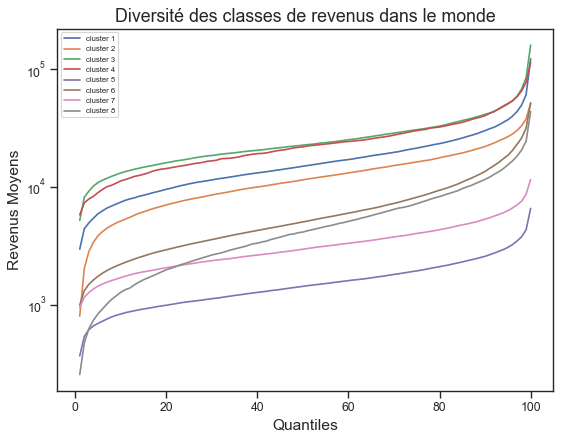

```python
figure(num=None, figsize=(8, 6), dpi=80, facecolor='w', edgecolor='k')

n=1
for i in selection["country_code"]:
    filtre = df["country_code"]==i
    plt.plot(df.loc[filtre, "quantile"], df.loc[filtre, "income"],
             label="cluster %d" %n)
    n+=1

plt.title("Diversité des classes de revenus dans le monde", fontsize=16)
plt.xlabel("Quantiles", fontsize=14)
plt.ylabel("Revenus Moyens", fontsize=14)
plt.yscale('symlog', linthreshx = 1)
plt.legend(fontsize=7)
plt.savefig("data/projet_7/graphiques/m2_2_diversite.png")
plt.show()
```

### III.2. Courbes de Lorenz

Nous allons donc afficher la courbe de Lorenz pour chaque pays sélectionné. Nous indiquerons chaque cluster dans le titre de chaque graphique.

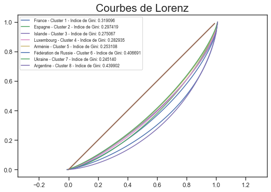

```python
figure(num=None, figsize=(7, 5), dpi=80, facecolor='w', edgecolor='k')

d,k=0,1
for i in selection["country"]:

    data=df.loc[df["country"]==i]
    revenus = data.income.values
    n = len(revenus)

    lorenz = np.append([0], np.cumsum(revenus)/sum(revenus))

    gini=selection["gini"][d]

    plt.axes().axis("equal")
    plt.plot(np.linspace(0-1/n, 1+1/n, n+1),
             lorenz, label=" %s - Cluster %d - Indice de Gini: %f" % (i, k, gini))

    X = arange(0,1,0.01)
    Y=X
    plot(X, Y)

    d+=1
    k+=1

plt.title("Courbes de Lorenz", fontsize=20)
plt.legend(fontsize=7.5)
plt.tight_layout()
plt.savefig("data/projet_7/graphiques/m2_3_lorenz.png")
plt.show()
```

Les indices de Gini calculés se situent entre 0,24 et 0,44. On constatera tout de même de bonnes inégalités en terme de distribution de revenus dans chaque pays. Tous éloignés de 0, on en déduit que les revenus ne sont pas équitablement répartis dans aucun état.

### III.3. Évolution de l'indice de Gini au fil des ans

Le DataFrame "gin" nous indique les indices de gini que la Banque Mondiale a pu estimer pour chaque pays au fil des ans. Nous ne conserverons que la période donnée dans notre base, à savoir les années 2004 à 2011, et uniquement les pays présents dans notre sélection.

```python
gin=pd.read_csv("data/projet_7/gini/api.csv", skiprows=[0,1,2])

#On supprime les colonnes inutiles et on renomme les deux premières:
gin=gin.drop(columns="Unnamed: 64")
gin.rename(columns={"Country Code": "country_code"}, inplace=True)
gin=gin.set_index("country_code")

#On ne garde que les années 2004 à 2011:
gin=gin.iloc[:, 47:]
gin=gin.iloc[:, 0:8]
gin=gin.reset_index()

#On ne conserve que les pays présent dans notre sélection:
gin=gin.loc[gin["country_code"].isin(selection["country_code"])==True]

#On le réordonne comme le DataFrame "selection":
sel=selection[["country_code"]].reset_index()
gin=pd.merge(gin, sel)
gin=gin.sort_values(by="index")
gin=gin.set_index("index")
gin=gin.reset_index()
gin=gin.drop(columns=["index"])

#Le DataFrame renvoie les indices de Gini en pourcentage, nous les divisons donc par 100:
gin.iloc[:, 1:]=gin.iloc[:, 1:]/100
gin
```

|  | country_code | 2004 | 2005 | 2006 | 2007 | 2008 | 2009 | 2010 | 2011 |
| --- | --- | --- | --- | --- | --- | --- | --- | --- | --- |
| 0 | FRA | 0.306 | 0.298 | 0.297 | 0.324 | 0.330 | 0.327 | 0.337 | 0.333 |
| 1 | ESP | 0.333 | 0.324 | 0.335 | 0.341 | 0.342 | 0.349 | 0.352 | 0.357 |
| 2 | ISL | 0.280 | 0.290 | 0.302 | 0.295 | 0.318 | 0.287 | 0.262 | 0.268 |
| 3 | LUX | 0.302 | 0.308 | 0.309 | 0.311 | 0.326 | 0.312 | 0.305 | 0.321 |
| 4 | ARM | 0.375 | 0.360 | 0.297 | 0.312 | 0.292 | 0.280 | 0.300 | 0.294 |
| 5 | RUS | 0.403 | 0.413 | 0.410 | 0.423 | 0.416 | 0.398 | 0.395 | 0.397 |
| 6 | UKR | 0.289 | 0.290 | 0.298 | 0.270 | 0.266 | 0.253 | 0.248 | 0.246 |
| 7 | ARG | 0.486 | 0.480 | 0.467 | 0.466 | 0.453 | 0.441 | 0.445 | 0.427 |

Nous allons donc maintenant représenter graphiquement pour ces 8 pays l'évolution de l'indice de Gini de 2004 à 2011.

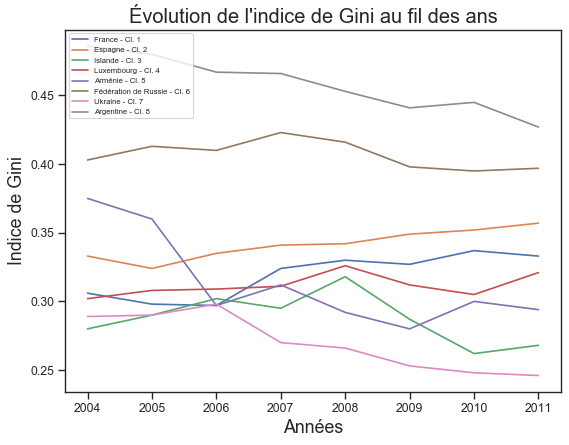

```python
figure(num=None, figsize=(8, 6), dpi=80, facecolor='w', edgecolor='k')

for i in gin.index:

    ans=pd.DataFrame(gin.iloc[i, 1:9]).reset_index()
    ans.columns=["year", "gini"]

    pays=selection["country"][i]
    groupe=selection["cluster"][i]

    plt.plot(ans.year, ans.gini, label=("%s - Cl. %d" %(pays, groupe)))

plt.legend(loc="upper left", fontsize=7)
plt.xlabel("Années", fontsize=16)
plt.ylabel("Indice de Gini", fontsize=16)
plt.title("Évolution de l'indice de Gini au fil des ans", fontsize=18)
plt.savefig("data/projet_7/graphiques/m2_3_gini.png")
plt.show()
```

### III.4. Classement des pays selon l'indice de Gini

Pour classer les pays choisis selon leur indice de Gini, il nous suffit de reprendre le DataFrame "selection" et de l'ordonner selon la variable "gini". On crée un DataFrame qui renvoie cette liste ordonnée que nous appellerons "classement".

```python
classement=selection[["country", "gini", "cluster"]].sort_values(by="gini").reset_index().drop(columns="index")
classement
```

|  | country | gini | cluster |
| --- | --- | --- | --- |
| 0 | Ukraine | 0.245140 | 7 |
| 1 | Arménie | 0.253108 | 5 |
| 2 | Islande | 0.275067 | 3 |
| 3 | Luxembourg | 0.282935 | 4 |
| 4 | Espagne | 0.297419 | 2 |
| 5 | France | 0.319096 | 1 |
| 6 | Fédération de Russie | 0.406691 | 6 |
| 7 | Argentine | 0.439902 | 8 |

Nous allons maintenant calculer la moyenne de ces indices de gini, ainsi que la moyenne des 4 pays présentant l'indice le plus bas, puis la moyenne des 4 présentant les plus haut.

```python
low_classement=classement.head(4)
top_classement=classement.tail(4)

print("Moyenne des 8 pays:", classement["gini"].mean())
print("Moyenne des 4 pays présentant les indices de gini les plus bas:", low_classement["gini"].mean())
print("Moyenne des 4 pays présentant les indices de gini le plus hauts:", top_classement["gini"].mean())
```

```
Moyenne des 8 pays: 0.3149196406299074
Moyenne des 4 pays présentant les indices de gini les plus bas: 0.2640623339174357
Moyenne des 4 pays présentant les indices de gini le plus hauts: 0.3657769473423791
```

La France semble présenter une distribution de revenus légèrement moins équitable que la plupart des autres pays du monde, mais son indice de gini n'est pas très éloigné de la moyenne générale.

# Mission 3: Génération des individus

# I. Coefficients d'élasticité

### I.1. Ajout des coefficients d'élasticité donnés par la World Bank

L'objectif de cette première partie de la mission 3 est de récupérer les coefficients d'élasticité propres à chaque pays présents dans notre base de données et de les ajouter à df. Le DataFrame suivant - qu'on appellera "gdi" - issu de la World Bank, nous indiquera ce coefficient pour une première partie de nos pays.

```python
gdi=pd.read_csv("data/projet_7/gdim.csv")
gdi=gdi[["wbcode", "year", "IGEincome"]]
gdi.rename(columns={"wbcode": "country_code", "IGEincome": "elasticity"}, inplace=True)
gdi=gdi.sort_values(by=["country_code", "year"])
gdi.sort_values(by="elasticity").drop_duplicates()
```

|  | country_code | year | elasticity |
| --- | --- | --- | --- |
| 1837 | FIN | 1960 | 0.112876 |
| 1472 | DNK | 1960 | 0.145146 |
| 5951 | TWN | 1960 | 0.181000 |
| 362 | BEL | 1960 | 0.183176 |
| 4527 | NOR | 1960 | 0.198667 |
| ... | ... | ... | ... |
| 6462 | ZAR | 1940 | NaN |
| 6468 | ZAR | 1950 | NaN |
| 6474 | ZAR | 1960 | NaN |
| 6486 | ZAR | 1980 | NaN |
| 6492 | ZMB | 1980 | NaN |

589 rows × 3 columns

Nous allons nous débarrasser des doublons de ce DataFrame, et conserver l'élasticité la plus récente pour les pays où elle est indiquée. Puis nous ajouterons une nouvelle colonne "elasticity" à df qui nous renverra déjà l'élasticité des pays où elle est indiquée dans gdi, et renverra un NaN pour ceux où elle ne l'est pas pour le moment.

```python
#Cration de la table "ela" qui représentera "gdi" sans les doublons avec, si elle est indiquée, l'élasticité la plus récente
#pour un pays donné:

ela=pd.DataFrame({"country_code": [],
                  "year": [],
                  "elasticity": []})

for i in gdi["country_code"].unique():
    loca=gdi["country_code"]==i
    if len(gdi.loc[loca].dropna())>0:
        ok=gdi.loc[loca].dropna()
        ok=ok.drop_duplicates()
        ela=pd.concat([ela, ok])
    else:
        ko=gdi.loc[loca].drop_duplicates(subset=["elasticity"])
        ela=pd.concat([ela, ko])

ela=ela.drop(columns="year")



#Ajout de la colonne "elasticity" à df:

df=pd.merge(df, ela, how="left")
df
```

|  | country_code | country | year | quantile | nb_quantiles | income | gdpppp | population | gini | cluster | elasticity |
| --- | --- | --- | --- | --- | --- | --- | --- | --- | --- | --- | --- |
| 0 | ALB | Albanie | 2008 | 1 | 100 | 728.89795 | 7297.0 | 3157000.0 | 0.294624 | 7 | 0.815874 |
| 1 | ALB | Albanie | 2008 | 2 | 100 | 916.66235 | 7297.0 | 3157000.0 | 0.294624 | 7 | 0.815874 |
| 2 | ALB | Albanie | 2008 | 3 | 100 | 1010.91600 | 7297.0 | 3157000.0 | 0.294624 | 7 | 0.815874 |
| 3 | ALB | Albanie | 2008 | 4 | 100 | 1086.90780 | 7297.0 | 3157000.0 | 0.294624 | 7 | 0.815874 |
| 4 | ALB | Albanie | 2008 | 5 | 100 | 1132.69970 | 7297.0 | 3157000.0 | 0.294624 | 7 | 0.815874 |
| ... | ... | ... | ... | ... | ... | ... | ... | ... | ... | ... | ... |
| 11595 | ZAF | Afrique du Sud | 2008 | 96 | 100 | 24553.56800 | 9602.0 | 50267000.0 | 0.659779 | 8 | 0.677000 |
| 11596 | ZAF | Afrique du Sud | 2008 | 97 | 100 | 28858.03100 | 9602.0 | 50267000.0 | 0.659779 | 8 | 0.677000 |
| 11597 | ZAF | Afrique du Sud | 2008 | 98 | 100 | 35750.29000 | 9602.0 | 50267000.0 | 0.659779 | 8 | 0.677000 |
| 11598 | ZAF | Afrique du Sud | 2008 | 99 | 100 | 46297.31600 | 9602.0 | 50267000.0 | 0.659779 | 8 | 0.677000 |
| 11599 | ZAF | Afrique du Sud | 2008 | 100 | 100 | 82408.55000 | 9602.0 | 50267000.0 | 0.659779 | 8 | 0.677000 |

11600 rows × 11 columns

On observe que nous n'avons pas encore l'ensemble des indices d'élasticité de tous les pays observés, ce qui fera l'objet de la sous-partie suivante.

```python
df["elasticity"].isnull().sum()
```

```
5300
```

### I.2. Ajout des coefficients d'élasticités restants

Nous allons donc maintenant repérer les pays de notre base de données pour lesquels l'élasticité n'a pas été relevée par gdi. Le DataFrame suivant, "estim_elasticity", propose une estimation de l'élasticité de chaque pays selon leur région continentale. Nous identifierons alors la liste des pays de df où l'élasticité n'est pas encore indiquée ainsi que la région continentale à laquelle appartient chacun de ces pays, puis nous leur attribuerons l'élasticité moyenne indiquée dans la colonne "Base case" du DataFrame "estim_eslasticity" définit ci-dessous.

```python
estim_elasticity=pd.read_csv("data/projet_7/elasticity.csv").set_index("Unnamed: 0")
estim_elasticity = estim_elasticity.rename_axis(None)
estim_elasticity
```

|  | Base case | Optimistic (high mobility) | Pessimistic (low mobility) |
| --- | --- | --- | --- |
| Nordic European countries and Canada | 0.20 | 0.15 | 0.3 |
| Europe (except nordic countries) | 0.40 | 0.30 | 0.5 |
| Australia/New Zealand/USA | 0.40 | 0.30 | 0.5 |
| Asia | 0.50 | 0.40 | 0.6 |
| Latin America/Africa | 0.66 | 0.50 | 0.9 |

```python
#Identification des pays de df dont l'élasticité reste à déterminer:

B=[i for i in df.loc[df["elasticity"].isnull()==True]["country"].unique()]
print(B)
```

```
['Argentine', 'Arménie', 'Azerbaïdjan', 'Burkina Faso', 'Bulgarie', 'Bhoutan', 'République centrafricaine', "Côte d'Ivoire", 'Cameroun', 'République du Congo', 'Costa Rica', 'République dominicaine', 'Estonie', 'Fidji', 'Géorgie', 'Honduras', 'Hongrie', 'Indonésie', "Iran (République islamique d')",…
```

```python
#Création de la liste des élasticités attribués dans "estim_elasticity" aux régions territoriales auxquelles appartiennent
#chacun de ces pays:

[a, b, c, d, e] = estim_elasticity["Base case"]

K=[e, d, d, e, b, d, e, e,
   e, d, e, b, c, b, e, b, d,
   d, d, a, d, d, b, d, e,
   d, b, b, e, b, e, e, e, e,
   d, b, e, b, e, e, b, e, d, d,
   d, d, b, b, e, e, d, d, e]


#Ajout des valeurs manquantes dans la colonne "elasticity" de "df":

CC=[i for i in df.loc[df["elasticity"].isnull()==True]["country_code"].unique()]

ajout=pd.DataFrame({"country_code": CC,
                  "elasticity": K})

ajout.head(10)
```

|  | country_code | elasticity |
| --- | --- | --- |
| 0 | ARG | 0.66 |
| 1 | ARM | 0.50 |
| 2 | AZE | 0.50 |
| 3 | BFA | 0.66 |
| 4 | BGR | 0.40 |
| 5 | BTN | 0.50 |
| 6 | CAF | 0.66 |
| 7 | CIV | 0.66 |
| 8 | CMR | 0.66 |
| 9 | COD | 0.50 |

Nous pouvons donc enfin ajouter les indices d'élasticités manquants dans df afin de compléter le DataFrame.

```python
for i in df.index:
    a=df["country_code"][i]
    if (a in list(ajout["country_code"]))==True:
        df["elasticity"][i]=list(ajout.loc[ajout["country_code"]==a]["elasticity"])[0]

df
```

|  | country_code | country | year | quantile | nb_quantiles | income | gdpppp | population | gini | cluster | elasticity |
| --- | --- | --- | --- | --- | --- | --- | --- | --- | --- | --- | --- |
| 0 | ALB | Albanie | 2008 | 1 | 100 | 728.89795 | 7297.0 | 3157000.0 | 0.294624 | 7 | 0.815874 |
| 1 | ALB | Albanie | 2008 | 2 | 100 | 916.66235 | 7297.0 | 3157000.0 | 0.294624 | 7 | 0.815874 |
| 2 | ALB | Albanie | 2008 | 3 | 100 | 1010.91600 | 7297.0 | 3157000.0 | 0.294624 | 7 | 0.815874 |
| 3 | ALB | Albanie | 2008 | 4 | 100 | 1086.90780 | 7297.0 | 3157000.0 | 0.294624 | 7 | 0.815874 |
| 4 | ALB | Albanie | 2008 | 5 | 100 | 1132.69970 | 7297.0 | 3157000.0 | 0.294624 | 7 | 0.815874 |
| ... | ... | ... | ... | ... | ... | ... | ... | ... | ... | ... | ... |
| 11595 | ZAF | Afrique du Sud | 2008 | 96 | 100 | 24553.56800 | 9602.0 | 50267000.0 | 0.659779 | 8 | 0.677000 |
| 11596 | ZAF | Afrique du Sud | 2008 | 97 | 100 | 28858.03100 | 9602.0 | 50267000.0 | 0.659779 | 8 | 0.677000 |
| 11597 | ZAF | Afrique du Sud | 2008 | 98 | 100 | 35750.29000 | 9602.0 | 50267000.0 | 0.659779 | 8 | 0.677000 |
| 11598 | ZAF | Afrique du Sud | 2008 | 99 | 100 | 46297.31600 | 9602.0 | 50267000.0 | 0.659779 | 8 | 0.677000 |
| 11599 | ZAF | Afrique du Sud | 2008 | 100 | 100 | 82408.55000 | 9602.0 | 50267000.0 | 0.659779 | 8 | 0.677000 |

11600 rows × 11 columns

# II. Distributions conditionnelles des revenus

### II.1. Construction d'un tableau des distributions conditionnelles selon une elasticité donnée

```python
#Nombre de quantiles:
nb_quantiles=100
rg=range(1, nb_quantiles+1)

#Nombre d'individus générés et coefficient d'élasticité choisi:
n=1000*nb_quantiles
pj=0.9

#Génération aléatoire des revenus des enfants et de leurs parents:
y_child, y_parent = generate_incomes(n, pj)
y_child, y_parent = pd.Series(y_child), pd.Series(y_parent)
y_child.head()
```

```
0    0.296488
1    1.357564
2    8.821937
3    1.764331
4    0.486557
dtype: float64
```

On détermine maintenant la classes de revenu de chaque enfant et de ses parents.

```python
#Classes de revenu des enfants:
c_i_child=quantiles(y_child, 100)

#Classes de revenu des parents:
c_i_parent=quantiles(y_parent, 100)

#Aperçut des classes de revenus:
sample=compute_quantiles(y_child, y_parent, nb_quantiles)
sample
```

|  | y_child | y_parents | c_i_child | c_i_parent |
| --- | --- | --- | --- | --- |
| 0 | 0.296488 | 0.484902 | 19 | 24 |
| 1 | 1.357564 | 1.923258 | 59 | 75 |
| 2 | 8.821937 | 1.170329 | 95 | 57 |
| 3 | 1.764331 | 2.607744 | 67 | 84 |
| 4 | 0.486557 | 0.512862 | 30 | 26 |
| ... | ... | ... | ... | ... |
| 99995 | 0.846101 | 0.388872 | 45 | 18 |
| 99996 | 4.458062 | 1.851472 | 87 | 74 |
| 99997 | 1.651818 | 1.603177 | 65 | 69 |
| 99998 | 2.313893 | 2.775362 | 74 | 85 |
| 99999 | 4.317594 | 2.438318 | 87 | 82 |

100000 rows × 4 columns

```python
cd=conditional_distributions(sample, nb_quantiles)

dis_rev=pd.DataFrame(cd,
                     columns=range(1, 101),
                     index=range(1, 101))

dis_rev
```

|  | 1 | 2 | 3 | 4 | 5 | 6 | 7 | 8 | 9 | 10 | ... | 91 | 92 | 93 | 94 | 95 | 96 | 97 | 98 | 99 | 100 |
| --- | --- | --- | --- | --- | --- | --- | --- | --- | --- | --- | --- | --- | --- | --- | --- | --- | --- | --- | --- | --- | --- |
| 1 | 0.243 | 0.131 | 0.079 | 0.070 | 0.061 | 0.053 | 0.045 | 0.037 | 0.026 | 0.023 | ... | 0.000 | 0.000 | 0.000 | 0.000 | 0.000 | 0.000 | 0.000 | 0.000 | 0.000 | 0.000 |
| 2 | 0.118 | 0.079 | 0.066 | 0.063 | 0.061 | 0.051 | 0.047 | 0.035 | 0.039 | 0.032 | ... | 0.000 | 0.000 | 0.000 | 0.000 | 0.000 | 0.000 | 0.000 | 0.000 | 0.000 | 0.000 |
| 3 | 0.097 | 0.081 | 0.063 | 0.058 | 0.048 | 0.034 | 0.039 | 0.031 | 0.037 | 0.038 | ... | 0.000 | 0.000 | 0.000 | 0.000 | 0.000 | 0.000 | 0.000 | 0.000 | 0.000 | 0.000 |
| 4 | 0.073 | 0.060 | 0.047 | 0.049 | 0.049 | 0.040 | 0.053 | 0.031 | 0.036 | 0.026 | ... | 0.000 | 0.000 | 0.000 | 0.000 | 0.000 | 0.000 | 0.000 | 0.000 | 0.000 | 0.000 |
| 5 | 0.059 | 0.060 | 0.051 | 0.051 | 0.037 | 0.044 | 0.045 | 0.024 | 0.037 | 0.020 | ... | 0.001 | 0.000 | 0.000 | 0.000 | 0.000 | 0.000 | 0.000 | 0.000 | 0.000 | 0.000 |
| ... | ... | ... | ... | ... | ... | ... | ... | ... | ... | ... | ... | ... | ... | ... | ... | ... | ... | ... | ... | ... | ... |
| 96 | 0.000 | 0.000 | 0.000 | 0.000 | 0.000 | 0.000 | 0.000 | 0.000 | 0.000 | 0.000 | ... | 0.030 | 0.034 | 0.040 | 0.041 | 0.045 | 0.037 | 0.035 | 0.050 | 0.037 | 0.049 |
| 97 | 0.000 | 0.000 | 0.000 | 0.000 | 0.000 | 0.000 | 0.000 | 0.000 | 0.000 | 0.000 | ... | 0.038 | 0.032 | 0.037 | 0.037 | 0.043 | 0.048 | 0.056 | 0.054 | 0.060 | 0.064 |
| 98 | 0.000 | 0.000 | 0.000 | 0.000 | 0.000 | 0.000 | 0.000 | 0.000 | 0.000 | 0.000 | ... | 0.031 | 0.028 | 0.041 | 0.034 | 0.052 | 0.045 | 0.059 | 0.068 | 0.074 | 0.096 |
| 99 | 0.000 | 0.000 | 0.000 | 0.000 | 0.000 | 0.000 | 0.000 | 0.000 | 0.000 | 0.000 | ... | 0.031 | 0.026 | 0.031 | 0.040 | 0.055 | 0.053 | 0.066 | 0.069 | 0.101 | 0.124 |
| 100 | 0.000 | 0.000 | 0.000 | 0.000 | 0.000 | 0.000 | 0.000 | 0.000 | 0.000 | 0.000 | ... | 0.025 | 0.031 | 0.034 | 0.047 | 0.033 | 0.050 | 0.076 | 0.087 | 0.121 | 0.237 |

100 rows × 100 columns

```python
p=dis_rev.loc[50, 47]
print("\nP(c_i_parent = {} | c_i_child = {}, pj = {}) = {}".format(47, 50, 0.4, p))
```

```
P(c_i_parent = 47 | c_i_child = 50, pj = 0.4) = 0.013
```

### II.2. Fonction génératrice des distributivités

Cette seconde sous-partie est une anticipation de la sous-partie suivante qui conclura la mission 3. Nous y présentons notamment la fonction qui nous permettra plus tard de construire les classes de revenu des parents des individus de la World Income Distribution. On généralise la sous-partie précédante en créant la fonction "tableau_distributivite" qui prendra en argument un indice d'élasticité pj, et qui nous renverra le tableau des distributions de revenus selon pj pour une population générée aléatoirement selon une loi normale, et un échantillonnage de 100 quantiles.

```python
def tableau_distributivite(pj):
    nb_quantiles=100
    n=500*nb_quantiles
    rg=range(1, nb_quantiles+1)

    y_child, y_parent = generate_incomes(n, pj)
    y_child, y_parent = pd.Series(y_child), pd.Series(y_parent)

    c_i_child=quantiles(y_child, nb_quantiles)
    c_i_parent=quantiles(y_parent, nb_quantiles)

    sample=compute_quantiles(y_child, y_parent, nb_quantiles)
    cd=conditional_distributions(sample, nb_quantiles)
    data=pd.DataFrame(cd,
                      columns=rg,
                      index=rg)
    return(data)
```

Pour une question pratique, nous utiliserons aussi la fonction "effectif" qui prend une série, et renvoie une nouvelle série qui comprend i fois le nombre k si l'index de k est i.

```python
def effectif(S):
    W=[]
    for i in S.index:
        nb=int(S[i])
        W+=[i]*nb
    return(W)
```

# III. Génération des classes de revenus

### III.1. Ajustement des données de base

Retirons dans un premier temps les colonnes de df qui ne nous servirons plus jusqu'à la fin du projet, et renommons, conformément à l'énoncé, la colonne "gdpppp" en "mj", que nous considérerons dorénavant comme le revenu moyen du pays, ainsi que la colonne "income" en "y_child", qui représentera maintenant le revenu des individus, et la colonne "quantile" en "c_i_child" qui représentera la classe de revenus de ces individus.

```python
df=df.drop(columns=["country", "nb_quantiles", "year", "cluster"])
df=df.rename(columns={"gdpppp": "mj",
                      "income": "y_child",
                      "quantile": "c_i_child"})
df
```

|  | country_code | c_i_child | y_child | mj | population | gini | elasticity |
| --- | --- | --- | --- | --- | --- | --- | --- |
| 0 | ALB | 1 | 728.89795 | 7297.0 | 3157000.0 | 0.294624 | 0.815874 |
| 1 | ALB | 2 | 916.66235 | 7297.0 | 3157000.0 | 0.294624 | 0.815874 |
| 2 | ALB | 3 | 1010.91600 | 7297.0 | 3157000.0 | 0.294624 | 0.815874 |
| 3 | ALB | 4 | 1086.90780 | 7297.0 | 3157000.0 | 0.294624 | 0.815874 |
| 4 | ALB | 5 | 1132.69970 | 7297.0 | 3157000.0 | 0.294624 | 0.815874 |
| ... | ... | ... | ... | ... | ... | ... | ... |
| 11595 | ZAF | 96 | 24553.56800 | 9602.0 | 50267000.0 | 0.659779 | 0.677000 |
| 11596 | ZAF | 97 | 28858.03100 | 9602.0 | 50267000.0 | 0.659779 | 0.677000 |
| 11597 | ZAF | 98 | 35750.29000 | 9602.0 | 50267000.0 | 0.659779 | 0.677000 |
| 11598 | ZAF | 99 | 46297.31600 | 9602.0 | 50267000.0 | 0.659779 | 0.677000 |
| 11599 | ZAF | 100 | 82408.55000 | 9602.0 | 50267000.0 | 0.659779 | 0.677000 |

11600 rows × 7 columns

### III.2. Création de l'échantillon

Reprenons maintenant df, et tirons-en le DataFrame "individus" qui représentera notre échantillon, en **multipliant chaque ligne de df par 500.**

```python
individus=pd.concat([df]*500)
individus=individus.sort_values(["country_code", "c_i_child"]).reset_index(drop=True)
individus=individus.reindex(columns=["country_code", "c_i_child", "y_child", "mj", "gini", "elasticity", "population"])

individus
```

|  | country_code | c_i_child | y_child | mj | gini | elasticity | population |
| --- | --- | --- | --- | --- | --- | --- | --- |
| 0 | ALB | 1 | 728.89795 | 7297.0 | 0.294624 | 0.815874 | 3157000.0 |
| 1 | ALB | 1 | 728.89795 | 7297.0 | 0.294624 | 0.815874 | 3157000.0 |
| 2 | ALB | 1 | 728.89795 | 7297.0 | 0.294624 | 0.815874 | 3157000.0 |
| 3 | ALB | 1 | 728.89795 | 7297.0 | 0.294624 | 0.815874 | 3157000.0 |
| 4 | ALB | 1 | 728.89795 | 7297.0 | 0.294624 | 0.815874 | 3157000.0 |
| ... | ... | ... | ... | ... | ... | ... | ... |
| 5799995 | ZAF | 100 | 82408.55000 | 9602.0 | 0.659779 | 0.677000 | 50267000.0 |
| 5799996 | ZAF | 100 | 82408.55000 | 9602.0 | 0.659779 | 0.677000 | 50267000.0 |
| 5799997 | ZAF | 100 | 82408.55000 | 9602.0 | 0.659779 | 0.677000 | 50267000.0 |
| 5799998 | ZAF | 100 | 82408.55000 | 9602.0 | 0.659779 | 0.677000 | 50267000.0 |
| 5799999 | ZAF | 100 | 82408.55000 | 9602.0 | 0.659779 | 0.677000 | 50267000.0 |

5800000 rows × 7 columns

### III.3. Ajout des classes de revenus des parents

Conformément à ce qui nous est demandé dans l'énoncé de la mission 3, nous allons ajouter au DataFrame "individus" une nouvelle colonne "c_i_parents" représentant la distribution des classes de revenus des parents, dont le taux d'aparitions d'une même classe de revenu pour un parent dont l'enfant présente une classe donné dans un pays donné (donc pour un coefficient d'élasticité donné) sera proportionnel à la probabilié d'appartenance de cette classe sachant ces derniers paramètres.

```python
df.to_csv("data/projet_7/transferts/df_before.csv", index=None)
individus.to_csv("data/projet_7/transferts/individus_before.csv", index=None)
```

L'exécution de l'instruction pour cet ajout étant trop volumineux pour mon matériel, **la partie suivante a donc été réalisée sur Collaboratory.** C'est pourquoi ci-dessus ont été enregistrés "df" et "individus", et est joint ci-dessous une capture d'écran du code exécuté sur Colaboratory pour obtenir "individus" doté de sa nouvelle colonne "c_i_parents".

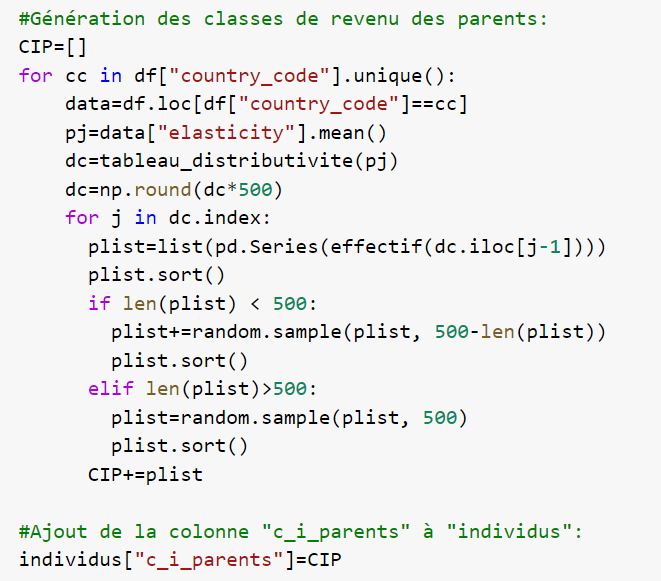

```python
#Génération de la colonne "c_i_parents":
Image(filename='data/projet_7/p7_capture_m3.png')
```

Ci-dessous, on rappelle alors le DataFrame "individus" avec la modification exécutée sur Collaboratory, à savoir l'ajout de la colonne "c_i_parents" qui renvoie pour chaque quantile d'un pays donné une liste de 500 classes de revenu des parents, conformément aux conditions demandées dans l'énoncé du projet.

```python
individus=pd.read_csv("data/projet_7/transferts/individus_after_m3.csv")
df=pd.read_csv("data/projet_7/transferts/df_before.csv")

individus.drop(columns=["mj", "country"], inplace=True)
individus.rename(columns={"gdpppp": "mj"}, inplace=True)
individus=individus.reindex(columns=["country_code", "c_i_child", "y_child", "mj", "gini",
                                     "c_i_parents", "elasticity", "population"])

#On peut visualiser la nouvelle colonne "c_i_parents" dans le DataFrame "individus":
individus
```

|  | country_code | c_i_child | y_child | mj | gini | c_i_parents | elasticity | population |
| --- | --- | --- | --- | --- | --- | --- | --- | --- |
| 0 | ALB | 1 | 728.89795 | 7297.0 | 0.294624 | 1 | 0.815874 | 3157000.0 |
| 1 | ALB | 1 | 728.89795 | 7297.0 | 0.294624 | 1 | 0.815874 | 3157000.0 |
| 2 | ALB | 1 | 728.89795 | 7297.0 | 0.294624 | 1 | 0.815874 | 3157000.0 |
| 3 | ALB | 1 | 728.89795 | 7297.0 | 0.294624 | 1 | 0.815874 | 3157000.0 |
| 4 | ALB | 1 | 728.89795 | 7297.0 | 0.294624 | 1 | 0.815874 | 3157000.0 |
| ... | ... | ... | ... | ... | ... | ... | ... | ... |
| 5799995 | ZAF | 100 | 82408.55000 | 9602.0 | 0.659779 | 100 | 0.677000 | 50267000.0 |
| 5799996 | ZAF | 100 | 82408.55000 | 9602.0 | 0.659779 | 100 | 0.677000 | 50267000.0 |
| 5799997 | ZAF | 100 | 82408.55000 | 9602.0 | 0.659779 | 100 | 0.677000 | 50267000.0 |
| 5799998 | ZAF | 100 | 82408.55000 | 9602.0 | 0.659779 | 100 | 0.677000 | 50267000.0 |
| 5799999 | ZAF | 100 | 82408.55000 | 9602.0 | 0.659779 | 100 | 0.677000 | 50267000.0 |

5800000 rows × 8 columns

Terminons cette mission 3 en supprimant la colonne ["c_i_child] et en ajoutant la colonne ["y_parents"]: Le revenu des parents basé sur le quantile "c_i_parents" du pays donné dans le tableau de base.

```python
#Suppression de la colonne "c_i_child":
individus=individus.drop(columns="c_i_child")

#Ajout de la colonne "y_parents":
income_p=df[["country_code", "c_i_child", "y_child"]]
income_p.columns=["country_code", "c_i_parents", "y_parents"]
individus=pd.merge(individus, income_p)


#Enfin, on réorganise les colonnes de "individus":
individus=individus.reindex(columns=["country_code", "y_child", "y_parents", "c_i_parents",
                                     "mj", "gini", "elasticity", "population"])

individus
```

|  | country_code | y_child | y_parents | c_i_parents | mj | gini | elasticity | population |
| --- | --- | --- | --- | --- | --- | --- | --- | --- |
| 0 | ALB | 728.89795 | 728.89795 | 1 | 7297.0 | 0.294624 | 0.815874 | 3157000.0 |
| 1 | ALB | 728.89795 | 728.89795 | 1 | 7297.0 | 0.294624 | 0.815874 | 3157000.0 |
| 2 | ALB | 728.89795 | 728.89795 | 1 | 7297.0 | 0.294624 | 0.815874 | 3157000.0 |
| 3 | ALB | 728.89795 | 728.89795 | 1 | 7297.0 | 0.294624 | 0.815874 | 3157000.0 |
| 4 | ALB | 728.89795 | 728.89795 | 1 | 7297.0 | 0.294624 | 0.815874 | 3157000.0 |
| ... | ... | ... | ... | ... | ... | ... | ... | ... |
| 5799995 | ZAF | 82408.55000 | 82408.55000 | 100 | 9602.0 | 0.659779 | 0.677000 | 50267000.0 |
| 5799996 | ZAF | 82408.55000 | 82408.55000 | 100 | 9602.0 | 0.659779 | 0.677000 | 50267000.0 |
| 5799997 | ZAF | 82408.55000 | 82408.55000 | 100 | 9602.0 | 0.659779 | 0.677000 | 50267000.0 |
| 5799998 | ZAF | 82408.55000 | 82408.55000 | 100 | 9602.0 | 0.659779 | 0.677000 | 50267000.0 |
| 5799999 | ZAF | 82408.55000 | 82408.55000 | 100 | 9602.0 | 0.659779 | 0.677000 | 50267000.0 |

5800000 rows × 8 columns

On notera que ce nouveau DataFrame contient finalement donc bien les 3 variables demandées:

- mj, le revenu moyen du pays j indiqué dans la colonne [mj].
- Gj, l'indice de Gini du pays j indiqué dans la colonne [gini].
- c_i_parent, la classe de revenu des parents d'un individu dans la colonne [c_i_parents].

On rappelle pour la mission 4 que nous avons conservé "df" avant la multiplication par 500 des individus.

# Mission 4 - Étude de la variance des revenus des individus

# I. Préliminaires des analyses à venir

### I.1. Récapitulatif et niveau de test

Nous réaliserons chaque test statistique au niveau de 5%. On rappelle dans la cellule suivante notre échantillon "individus" décrit à la fin de la mission précédente, et on en profite pour fixer notre niveau de test nt pour toute modélisation qui s'exécutera dans toute la suite du projet.

```python
#Fixation du niveau de test:
nt=0.05

#Chacun des tests sera basé sur notre nouvelle base de données "individus":
individus
```

|  | country_code | y_child | y_parents | c_i_parents | mj | gini | elasticity | population |
| --- | --- | --- | --- | --- | --- | --- | --- | --- |
| 0 | ALB | 728.89795 | 728.89795 | 1 | 7297.0 | 0.294624 | 0.815874 | 3157000.0 |
| 1 | ALB | 728.89795 | 728.89795 | 1 | 7297.0 | 0.294624 | 0.815874 | 3157000.0 |
| 2 | ALB | 728.89795 | 728.89795 | 1 | 7297.0 | 0.294624 | 0.815874 | 3157000.0 |
| 3 | ALB | 728.89795 | 728.89795 | 1 | 7297.0 | 0.294624 | 0.815874 | 3157000.0 |
| 4 | ALB | 728.89795 | 728.89795 | 1 | 7297.0 | 0.294624 | 0.815874 | 3157000.0 |
| ... | ... | ... | ... | ... | ... | ... | ... | ... |
| 5799995 | ZAF | 82408.55000 | 82408.55000 | 100 | 9602.0 | 0.659779 | 0.677000 | 50267000.0 |
| 5799996 | ZAF | 82408.55000 | 82408.55000 | 100 | 9602.0 | 0.659779 | 0.677000 | 50267000.0 |
| 5799997 | ZAF | 82408.55000 | 82408.55000 | 100 | 9602.0 | 0.659779 | 0.677000 | 50267000.0 |
| 5799998 | ZAF | 82408.55000 | 82408.55000 | 100 | 9602.0 | 0.659779 | 0.677000 | 50267000.0 |
| 5799999 | ZAF | 82408.55000 | 82408.55000 | 100 | 9602.0 | 0.659779 | 0.677000 | 50267000.0 |

5800000 rows × 8 columns

### I.2. Ajout des variables logarithmiques

Dans le cadre des modélisations à venir, nous ajoutons à "individus" les colonnes "log_y_child", "log_y_parents" et "log_mj", respectivements les données de "y_child", "y_parents" et "mj" exprimées en logarithme. Nous ajoutons également "log_y_child" à df car cela va nous être utile dans la partie suivante.

```python
df["log_y_child"]=np.log(df["y_child"])
individus["log_y_child"]=np.log(individus["y_child"])
individus["log_mj"]=np.log(individus["mj"])
individus["log_y_parents"]=np.log(individus["y_parents"])
individus
```

|  | country_code | y_child | y_parents | c_i_parents | mj | gini | elasticity | population | log_y_child | log_mj | log_y_parents |
| --- | --- | --- | --- | --- | --- | --- | --- | --- | --- | --- | --- |
| 0 | ALB | 728.89795 | 728.89795 | 1 | 7297.0 | 0.294624 | 0.815874 | 3157000.0 | 6.591534 | 8.895219 | 6.591534 |
| 1 | ALB | 728.89795 | 728.89795 | 1 | 7297.0 | 0.294624 | 0.815874 | 3157000.0 | 6.591534 | 8.895219 | 6.591534 |
| 2 | ALB | 728.89795 | 728.89795 | 1 | 7297.0 | 0.294624 | 0.815874 | 3157000.0 | 6.591534 | 8.895219 | 6.591534 |
| 3 | ALB | 728.89795 | 728.89795 | 1 | 7297.0 | 0.294624 | 0.815874 | 3157000.0 | 6.591534 | 8.895219 | 6.591534 |
| 4 | ALB | 728.89795 | 728.89795 | 1 | 7297.0 | 0.294624 | 0.815874 | 3157000.0 | 6.591534 | 8.895219 | 6.591534 |
| ... | ... | ... | ... | ... | ... | ... | ... | ... | ... | ... | ... |
| 5799995 | ZAF | 82408.55000 | 82408.55000 | 100 | 9602.0 | 0.659779 | 0.677000 | 50267000.0 | 11.319444 | 9.169727 | 11.319444 |
| 5799996 | ZAF | 82408.55000 | 82408.55000 | 100 | 9602.0 | 0.659779 | 0.677000 | 50267000.0 | 11.319444 | 9.169727 | 11.319444 |
| 5799997 | ZAF | 82408.55000 | 82408.55000 | 100 | 9602.0 | 0.659779 | 0.677000 | 50267000.0 | 11.319444 | 9.169727 | 11.319444 |
| 5799998 | ZAF | 82408.55000 | 82408.55000 | 100 | 9602.0 | 0.659779 | 0.677000 | 50267000.0 | 11.319444 | 9.169727 | 11.319444 |
| 5799999 | ZAF | 82408.55000 | 82408.55000 | 100 | 9602.0 | 0.659779 | 0.677000 | 50267000.0 | 11.319444 | 9.169727 | 11.319444 |

5800000 rows × 11 columns

### I.3. Fonctions utilitaires sur les résidus des modélisations

En vue des analyses répétées que nous exécuterons sur les **résidus des modélisations** à venir, nous créons ici les fonctions décrites ci-dessous qui prendront toutes en entrée une modélisation donnée pour renvoyer un certain résultat sur ses résidus. À noter que les différents tests d'adéquation à une loi gausienne que nous exécuterons testeront donc l'adéquation d'une certaine variable X à la loi normale de paramètres (mean(X), std(X)).

- 1°) **"residus_henry"**: qui nous superposera les résidus d'une modélisation donnée avec la droite de Henry.
- 2°) **"nuage_residuel"**: qui nous renverra le nuage de la variance résiduelle.
- 3°) **"test_shapiro"**: qui nous renverra les résultats d'un test de Shapiro sur les résidus (peu probable qu'on s'en serve vu la taille des échantillons) .
- 4°) **"test_residus_KS"**: qui nous renverra les résultats d'un test de Kolmogorov-Smirnoff sur les résidus.
- 5°) **"test_residus_BP"**: qui nous renverra les résultats d'un test de Breusch-Pagan sur les résidus en vue de l'analyse de leur **homoscédasticité**.

Pour chaque analyse des résidus d'un modèle de régression, nous observerons son éventuelle adéquation à la loi normale sur la droite de Henry, et son homoscédasticité sur le nuage de variance résiduelle.

```python
# 1°) Droite de Henry:
def residus_henry(MODEL, nom, couleur):
    sm.qqplot(MODEL.resid, line="45", fit=True, color=couleur)
    plt.title("Droite de Henry - Résidus de %s" %nom, fontsize=18)
    plt.xlabel("Quantiles théoriques" ,fontsize=14)
    plt.ylabel("Quantiles observés", fontsize=14)

# 2°) Nuage de la variance résiduelle:
def nuage_residuel(MODEL, nom, couleur):
    plt.plot(MODEL.fittedvalues, MODEL.resid, ".", color=couleur, alpha=0.3)
    plt.title("Nuage de la variance résiduelle - %s" %nom, fontsize=18)
    plt.xlabel("Revenu des individus", fontsize=16)
    plt.ylabel("Résidus", fontsize=16)

# 3°) Test de Shapiro:
def test_shapiro(MODEL):
    SH=shapiro(MODEL.resid)
    print("TEST DE SHAPIRO:", " statistic =", SH[0], " pvalue =", SH[1])

# 4°) Test de Kolmogorov-Smirnov:
def test_residus_KS(MODEL):
    MR=MODEL.resid
    KS=ks_2samp(MR,list(np.random.normal(MR.mean(), MR.std(), len(MR))))
    print("TEST DE KOLMOGOROV-SMIRNOV:", " statistic =", KS[0], " pvalue =", KS[1])

# 5°) Test de Breusch-Pagan:
def test_residus_BP(MODEL):
    BP=sm.stats.diagnostic.het_breuschpagan(MODEL.resid, MODEL.model.exog)
    print("TEST DE BREUSCH-PAGAN:", " statistic =", BP[0], " pvalue =", BP[1])
```

### I.4. Fonctions utilitaires sur les régressions linéaires multiples et leurs variables

Les analyses de la mission 4 se porteront notamment sur diverses modélisations de données. Pour chaque régression linéaire multiple que nous exécuterons, il nous faudra analyser **la multicolinéarité** des variables explicatives incluses dans le modèle. La fonction suivante "VIF" nous prendra en argument un modèle de régression linéaire multiple donné et la liste des variables explicatives du dit-modèle pour nous renvoyer un DataFrame indiquant le facteur d'influence de la variance (VIF en anglais) de chacune de ces variables explicatives au cours de la modélisation.

```python
def VIF(RLM, variables):
    MEX=RLM.model.exog
    return(pd.DataFrame({"VIF de la variable": [variance_inflation_factor(MEX, i) for i in np.arange(1, MEX.shape[1])]},
                       index=variables))
```

Nous créons également, ici, la fonction "decomposition_des_variables" qui, pour une régression linéaire multiple donnée, nous renverra directement un DataFrame affichant pour chaque variable explicative **le pourcentage d'explication de la variance** du revenu des individus.

```python
def decomposition_des_variables(RLM):
    data=sm.stats.anova_lm(RLM, typ=1)
    ssq=data[["sum_sq"]]
    ssq=np.round(100*ssq/ssq.sum(), 2)
    ssq["sum_sq"]=ssq.sum_sq
    ssq.columns=["Pourcentage de l'explication de la variance"]
    return(ssq)
```

# II. Revenus des individus selon leur pays d'origine - ANOVA

### II.1. Aperçu de l'influence du pays d'origine sur le revenu

Dans cette première partie, on se demande si le pays d'origine a une influence sur le revenu de l'individu. En vue d'une ANOVA sur le revenu en ne considérant que le pays d'origine comme variable explicative, nous allons dans un premier temps rappeler un aperçu de la diversité des revenus dans les pays étudiés. Étant donné que les variables "country_code" et "y_child" de "individus" sont celles de "df" répétées 500 fois, nous utiliserons dans cette première partie df au lieu de "individus" en dépit du poids de ce dernier DataFrame, cela ne changera rien à nos résultats.

**Nous observerons que les boxplots suivantes indiquent déjà qu'il y a bien un effet "pays" sur les revenus.**

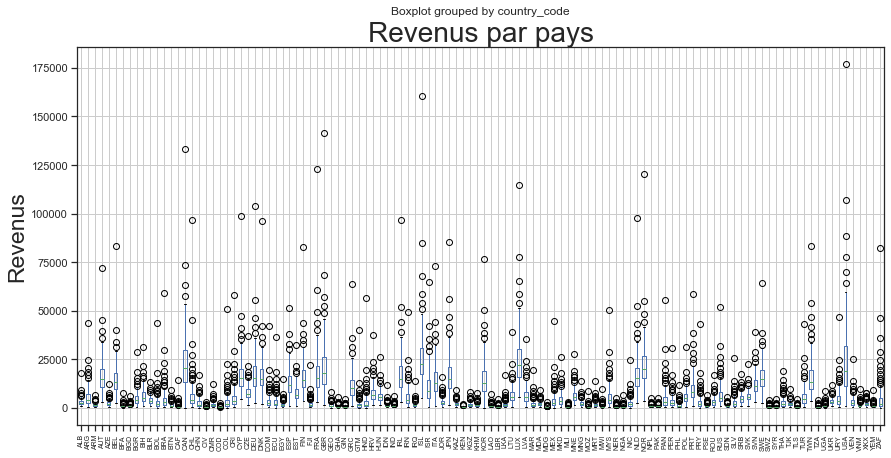

```python
fig, ax = plt.subplots(figsize=(14,7))

df.boxplot(column="y_child",by="country_code", ax=ax)

plt.title("Revenus par pays", fontsize=28)
plt.ylabel("Revenus", fontsize=23)
plt.xlabel("")
plt.xticks(rotation=90, fontsize=7)
plt.savefig("data/projet_7/graphiques/m4_21_boxplots.png")
plt.show()
```

### II.2. Modélisation et évaluation du modèle

On modélise alors ici notre ANOVA que nous appellerons "AN". Le DataFrame "individus" étant trop volumineux pour cette exécution, nous la ferons sur df (qui est toujours notre modèle de base avant d'avoir multiplité chaque ligne par 500 au cours de la mission 3), ce qui ne changera rien à nos résultats étant donnée que les salaires sont identiquement répétés 500 fois pour chaque pays dans "individus".

```python
AN = ols("y_child ~ country_code", data=df).fit(alpha=nt) #On rappelle que nt=0,05.
AN.summary().tables[0]
```

OLS Regression Results

| Dep. Variable: | y_child | R-squared: | 0.496 |
| --- | --- | --- | --- |
| Model: | OLS | Adj. R-squared: | 0.491 |
| Method: | Least Squares | F-statistic: | 98.43 |
| Date: | Sun, 16 Aug 2020 | Prob (F-statistic): | 0.00 |
| Time: | 12:15:47 | Log-Likelihood: | -1.1862e+05 |
| No. Observations: | 11600 | AIC: | 2.375e+05 |
| Df Residuals: | 11484 | BIC: | 2.383e+05 |
| Df Model: | 115 |  |  |
| Covariance Type: | nonrobust |  |  |

Le coefficient de détermination donné par R-squared dans le modèle indique la performance du modèle. On notera toutefois qu'il diffère, ici, du coefficient de détermination ajusté.

```python
print("Coefficient de détermination:", AN.rsquared)
print("Le pays d'origine explique environ", 100*round(AN.rsquared, 3), "% de  la variance de y_child")
```

```
Coefficient de détermination: 0.4963901423109953
Le pays d'origine explique environ 49.6 % de  la variance de y_child
```

### II.3. Test de Fisher

Nous allons exécuter un test de Fisher sur nos données. On émet alors les deux hypothèses suivantes:

- H0: Le pays d'origine n'a aucune influence sur le revenu de l'individu.
- H1: Le pays d'origine conditione le revenu de l'individu.

La validation de H0 se confirmera si les différences entre chaque revenu ne sont pas significatives, à contrario de H1 qui sera validé si elles le sont.

```python
sm.stats.anova_lm(AN, typ=1)
```

|  | df | sum_sq | mean_sq | F | PR(>F) |
| --- | --- | --- | --- | --- | --- |
| country_code | 115.0 | 5.102375e+11 | 4.436848e+09 | 98.429271 | 0.0 |
| Residual | 11484.0 | 5.176586e+11 | 4.507651e+07 | NaN | NaN |

La pvalue étant infinitésimalement proche de 0, on peut au niveau de test de 5% **rejeter H0 et admettre H1**: ainsi on en conclu, selon ce test, que le pays d'origine influe bien sur les revenus.

### II.4. Analyse des résidus

```python
test_residus_KS(AN)
```

```
TEST DE KOLMOGOROV-SMIRNOV:  statistic = 0.2399137931034483  pvalue = 2.1441387185603444e-290
```

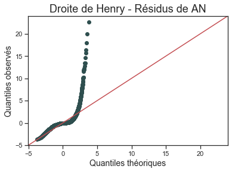

```python
residus_henry(AN, "AN", "darkslategrey")
plt.savefig("data/projet_7/graphiques/m4_24_henryAN.png")
plt.show()
```

À la vue de la droite de Henry, les points ne sont pas alignés et l'on remarque un grand nombre de points éloignés de la moyenne, ce qui laisse fortement supposer que les résidus ne suivent pas une loi normale, pas même si l'on supprimait quelques pays à forte influence de nos observations.

```python
test_residus_BP(AN)
```

```
TEST DE BREUSCH-PAGAN:  statistic = 424.6129209876246  pvalue = 4.7252910983452885e-37
```

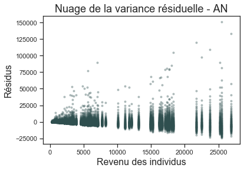

```python
nuage_residuel(AN, "AN", "darkslategrey")
plt.savefig("data/projet_7/graphiques/m4_24_nuageAN.png")
plt.show()
```

Le nuage de la variance résiduelle montre clairement que la variance des résidus n'est pas constante et le test de Breusch-Pagan affichant une pvalue proche de 0, on rejette alors l'homoscédasticité des résidus.

### II.5. Reprise de l'ANOVA en passant les revenus des individus au logarithme

Nous allons ajouter à df la variable "log_y_child" qui sera la variable "y_child" exprimée en logarithme, puis, les résultats de la première ANOVA laissant quelque peu à désirer en dépit de l'analyse des résidus. Nous réaliserons à nouveau chacune des étape précédente pour cette nouvelle ANOVA, à commencer par les boîtes à moustaches.

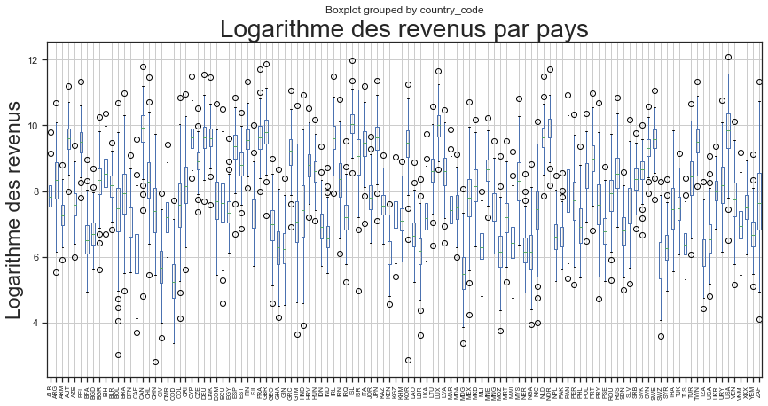

```python
fig, ax = plt.subplots(figsize=(14,7))

df.boxplot(column="log_y_child",by="country_code", ax=ax)

plt.title("Logarithme des revenus par pays", fontsize=28)
plt.ylabel("Logarithme des revenus", fontsize=23)
plt.xlabel("")
plt.xticks(rotation=90, fontsize=7)
plt.savefig("data/projet_7/graphiques/m4_25_boxplots_log.png")
plt.show()
```

Le passage au logarithme permet effectivement de diminuer le volume de grands nombres représentants une série. On observe toujours une irrégularité de la variance des revenus, mais déjà une distribution plus serrée. Avec comme variable explicative "country_code" et comme varialbe à expliquer "log_y_child", on réalise maintenant l'ANOVA dont nous appellerons "AN2" la modélisation.

```python
AN2 = ols("log_y_child ~ country_code", data=df).fit(alpha=nt)
AN2.summary().tables[0]
```

OLS Regression Results

| Dep. Variable: | log_y_child | R-squared: | 0.729 |
| --- | --- | --- | --- |
| Model: | OLS | Adj. R-squared: | 0.727 |
| Method: | Least Squares | F-statistic: | 269.0 |
| Date: | Sun, 16 Aug 2020 | Prob (F-statistic): | 0.00 |
| Time: | 12:16:03 | Log-Likelihood: | -12627. |
| No. Observations: | 11600 | AIC: | 2.549e+04 |
| Df Residuals: | 11484 | BIC: | 2.634e+04 |
| Df Model: | 115 |  |  |
| Covariance Type: | nonrobust |  |  |

On relève dans le sommaire de la modélisation le R-squared qui évalue la performance du modèle en nous donnant le pourcentage d'explication de la variance des revenus des individus.

```python
print("Coefficient de détermination:", AN2.rsquared)
print("Le pays d'origine explique environ", round(100*AN2.rsquared, 2), "% de  la variance de log_y_child")
```

```
Coefficient de détermination: 0.7292381117731964
Le pays d'origine explique environ 72.92 % de  la variance de log_y_child
```

On peut d'ores et déjà admettre que le passage au logarithme des revenus nous permet de modéliser un modèle bien plus performant que le précédent, avec **72,92%** d'explication de variance, contre 49,6% pour le précédent. Soulignons l'effet du pays sur les revenus malgré la réduction de leur variance lors du passage au logarithme par le test de Fisher.

```python
sm.stats.anova_lm(AN2, typ=1)
```

|  | df | sum_sq | mean_sq | F | PR(>F) |
| --- | --- | --- | --- | --- | --- |
| country_code | 115.0 | 16134.417851 | 140.299286 | 268.95348 | 0.0 |
| Residual | 11484.0 | 5990.615921 | 0.521649 | NaN | NaN |

La pvalue étant nulle, à nouveau, nous concluons également à une influence significative du pays d'origine sur les revenus des individus malgré leur variance réduite, ce qui au passage, appui davantage cette même conclusion pour le modèle précédent. Nous allons maintenant analyser les résidus de cette seconde ANOVA, en testant cette fois-ci simultanément leur distribution par un test de Kolmogorov-Smirnov et leur homoscédasticité par un test de Breusch-Pagan.

```python
#Test de Kolmogorov-Smirnov:
test_residus_KS(AN2)

#Test de Breusch-Pagan:
test_residus_BP(AN2)
```

```
TEST DE KOLMOGOROV-SMIRNOV:  statistic = 0.03767241379310346  pvalue = 1.4167960279296344e-07
TEST DE BREUSCH-PAGAN:  statistic = 787.4802306199234  pvalue = 9.29799003268876e-101
```

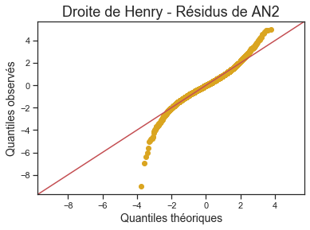

```
____________________________________________________________
```

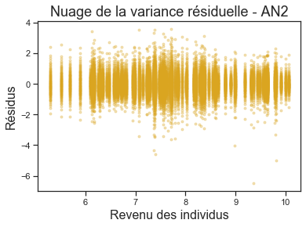

```python
#Droite de Henry:
residus_henry(AN2, "AN2", "goldenrod")
plt.savefig("data/projet_7/graphiques/m4_25_henryAN2.png")
plt.show()

print("_"*60)

#Nuage de la variance résiduelle:
nuage_residuel(AN2, "AN2", "goldenrod")
plt.savefig("data/projet_7/graphiques/m4_25_nuageAN2.png")
plt.show()
```

On observe donc sur la droite de Henry un bien meilleur alignement des résidus que pour le modèle précédent. En analysant cette droite, les données semblent suivrent une loi normale excepté pour une poignée d'outliers influants sur le modèle. De plus, on observe sur le nuage résiduel une tendance à la constance des variances. Nous étudierons plus tard dans la mission les individus faussant les résultats des tests statistiques précédents, mais nous pouvons, a priori, nous fier à cette nouvelle ANOVA selon les deux graphiques ci-dessus. Ce modèle est clairement plus fiable que le précédent, en plus d'être plus significatif à la vue des pourcentages d'explication de la variance.

# III. Régressions linéaires multiples sur le revenu des individus

### III.1. Revenu moyen du pays et indice de Gini - Premier modèle selon les données actuelles

On suppose qu'il existe une relation linéaire entre la variable à expliquer y_child et les variables explicatives mj et gini, donc qu'il existe des paramètres b1, b2 et r tels que: **y_child = b1 x mj + b2 x gini + r**.

On émet deux à deux les quatre hypothèses de test:

- H0: b1=0 - le paramètre de la variable mj n'est pas significatif.
- H1: b1≠0 - le paramètre de la variable mj est significatif.
- G0: b2=0 - le paramètre de la variable gini n'est pas significatif.
- G1: b2≠0 - le paramètre de la variable gini est significatif.

On effectue maintenant le test de régression linéaire sur y_child selon les variables mj et gini. On appellera "RL1" cette modélisation.

```python
RL1=ols("y_child ~ mj+gini", data=individus).fit(alpha=nt)
RL1.summary()
```

OLS Regression Results

| Dep. Variable: | y_child | R-squared: | 0.448 |
| --- | --- | --- | --- |
| Model: | OLS | Adj. R-squared: | 0.448 |
| Method: | Least Squares | F-statistic: | 2.351e+06 |
| Date: | Sun, 16 Aug 2020 | Prob (F-statistic): | 0.00 |
| Time: | 12:16:14 | Log-Likelihood: | -5.9578e+07 |
| No. Observations: | 5800000 | AIC: | 1.192e+08 |
| Df Residuals: | 5799997 | BIC: | 1.192e+08 |
| Df Model: | 2 |  |  |
| Covariance Type: | nonrobust |  |  |

|  | coef | std err | t | P>\|t\| | [0.025 | 0.975] |
| --- | --- | --- | --- | --- | --- | --- |
| Intercept | -632.9452 | 14.798 | -42.773 | 0.000 | -661.949 | -603.942 |
| mj | 0.4857 | 0.000 | 2010.627 | 0.000 | 0.485 | 0.486 |
| gini | 1783.8890 | 35.384 | 50.416 | 0.000 | 1714.538 | 1853.240 |

| Omnibus: | 7170721.799 | Durbin-Watson: | 0.114 |
| --- | --- | --- | --- |
| Prob(Omnibus): | 0.000 | Jarque-Bera (JB): | 1903999691.910 |
| Skew: | 6.545 | Prob(JB): | 0.00 |
| Kurtosis: | 90.791 | Cond. No. | 2.37e+05 |

Warnings:  
[1] Standard Errors assume that the covariance matrix of the errors is correctly specified.  
[2] The condition number is large, 2.37e+05. This might indicate that there are  
strong multicollinearity or other numerical problems.

Nous obtenons que les 2 pvalues sont de 0 pour chacune des deux variables, ce qui nous conduit à:

- **rejeter H0 et admettre H1**.
- **rejeter G0 et admettre G1**.

Les deux variables mj et gini sont alors significatives au niveau de test de 5%. Testons néanmoins leur éventuelle colinéarité.

```python
VIF(RL1, ["mj", "gini"])
```

|  | VIF de la variable |
| --- | --- |
| mj | 1.185672 |
| gini | 1.185672 |

Les deux facteurs d'influence sur la variance sont inférieurs à 10. Il n'y a donc pas de problème de colinéarité dans notre modèle.

### III.2. Revenu moyen du pays et indice de Gini - Second modèle selon les données exprimées en logarithme

On suppose qu'il existe une relation linéaire entre la variable à expliquer log_y_child et les variables explicatives log_mj et gini, donc qu'il existe des paramètres b1, b2 et r tels que: **log_y_child = b1 x log_mj + b2 x gini + r**.

On émet deux à deux les quatre hypothèses de test:

- H0: b1=0 - le paramètre de la variable log_mj n'est pas significatif.
- H1: b1≠0 - le paramètre de la variable log_mj est significatif.
- G0: b2=0 - le paramètre de la variable gini n'est pas significatif.
- G1: b2≠0 - le paramètre de la variable gini est significatif.

On effectue maintenant le test de régression linéaire sur log_y_child selon les variables log_mj et gini. On appelle ce second modèle "RL2", et "srl_2" son sommaire.

```python
RL2=ols("log_y_child ~ log_mj+gini", data=individus).fit(alpha=nt)
RL2.summary()
```

OLS Regression Results

| Dep. Variable: | log_y_child | R-squared: | 0.652 |
| --- | --- | --- | --- |
| Model: | OLS | Adj. R-squared: | 0.652 |
| Method: | Least Squares | F-statistic: | 5.429e+06 |
| Date: | Sun, 16 Aug 2020 | Prob (F-statistic): | 0.00 |
| Time: | 12:16:25 | Log-Likelihood: | -7.0428e+06 |
| No. Observations: | 5800000 | AIC: | 1.409e+07 |
| Df Residuals: | 5799997 | BIC: | 1.409e+07 |
| Df Model: | 2 |  |  |
| Covariance Type: | nonrobust |  |  |

|  | coef | std err | t | P>\|t\| | [0.025 | 0.975] |
| --- | --- | --- | --- | --- | --- | --- |
| Intercept | 0.7721 | 0.003 | 234.835 | 0.000 | 0.766 | 0.779 |
| log_mj | 0.8656 | 0.000 | 3016.633 | 0.000 | 0.865 | 0.866 |
| gini | -1.4920 | 0.004 | -376.609 | 0.000 | -1.500 | -1.484 |

| Omnibus: | 196030.739 | Durbin-Watson: | 0.048 |
| --- | --- | --- | --- |
| Prob(Omnibus): | 0.000 | Jarque-Bera (JB): | 531495.049 |
| Skew: | -0.102 | Prob(JB): | 0.00 |
| Kurtosis: | 4.469 | Cond. No. | 125. |

Warnings:  
[1] Standard Errors assume that the covariance matrix of the errors is correctly specified.

Nous obtenons que les 2 pvalues sont de 0 pour chacune des deux variables, donc b1 et b2 sont significativement différents de 0, ce qui nous conduit à:

- **rejeter H0 et admettre H1**.
- **rejeter G0 et admettre G1**.

Les deux variables log_mj et gini sont alors significatives au niveau de test de 5%. Testons également leur colinéarité.

```python
VIF(RL2, ["log_mj", "gini"])
```

|  | VIF de la variable |
| --- | --- |
| log_mj | 1.095369 |
| gini | 1.095369 |

Les deux facteurs d'influence sur la variance sont inférieurs à 10. Il n'y a donc pas de problème de colinéarité dans notre modèle non plus.

### III.3. Comparaison des deux modèles: Coefficients de détermination et analyse des résidus

Nous allons analyser le pourcentage de la variance expliquée des revenus par chacun des deux derniers modèles de régressions linéraires RL1 où les données sont inchangées et RL2 où les données sont exprimées en logarithme. Les droites de Henry sur les résidus de chacune des deux régressions linéaires précédentes nous indiqueront lesquels sont le plus en adéquation avec la loi gaussienne.

```
COEFFICIENT DE DÉTERMINATION DE RL1 - SANS PASSER AU LOGARITHME: 0.4477
```

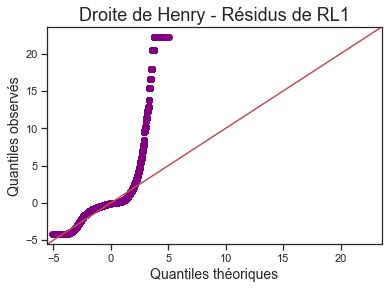

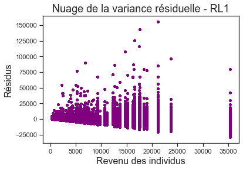

```
____________________________________________________________

COEFFICIENT DE DÉTERMINATION DE RL2 - EN PASSANT AU LOGARITHME: 0.6518
```

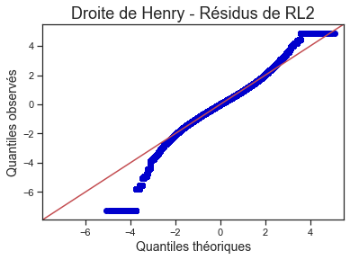

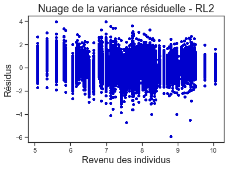

```python
#Analyse de la première régression linéaire sans passer au logarithme:
print("COEFFICIENT DE DÉTERMINATION DE RL1 - SANS PASSER AU LOGARITHME:", round(RL1.rsquared, 4))
residus_henry(RL1, "RL1", "purple")
plt.savefig("data/projet_7/graphiques/m4_33_henry_RL1.png")
plt.show()
nuage_residuel(RL1, "RL1", "purple")
plt.savefig("data/projet_7/graphiques/m4_33_nuage_RL1.png")
plt.show()

print("_"*60)
print(" ")

#Analyse de la seconde régression linéaire en passant au logarithme:
print("COEFFICIENT DE DÉTERMINATION DE RL2 - EN PASSANT AU LOGARITHME:", round(RL2.rsquared, 4))
residus_henry(RL2, "RL2", "mediumblue")
plt.savefig("data/projet_7/graphiques/m4_33_henry_RL2.png")
plt.show()
nuage_residuel(RL2, "RL2", "mediumblue")
plt.savefig("data/projet_7/graphiques/m4_33_nuage_RL2.png")
plt.show()
```

Le pourcentage de la variance expliquée par le **premier modèle est d'environ 44,77%** tandis que celui du **second modèle est proche de 65,18%**, donc un coefficient de détermination plus élevé pour RL2 que pour RL1.

**Les droites de Henry** indiquent clairement que les résidus du second modèle (en passant au logarithme) sont bien plus en adéquation avec une loi gaussienne que ne le sont les résidus du premier modèle:

- Pour le premier modèle, sans passer au logarithme, nous observons un éparpillement total des résidus, comme pour la dernière modélisation, aucunement une adéquation à la loi gaussienne, et nul échantillonnage raisonnable de nos individus ne semblerait y remédier.
- Pour la deuxième régression linéaire, en revanche, où l'on passe au logarithme, la distribution empirique des résidus semble suivre une loi gaussienne selon la droite de Henry, excepté pour les valeurs faibles des résidus.

**Les nuages de variance résiduelle** indiquent clairement que les résidus du second modèle (en passant au logarithme) sont bien plus proches:

- Pour le premier modèle, sans passer au logarithme, les variances diffèrent significativement.
- Pour la deuxième régression linéaire, en revanche, où l'on passe au logarithme, les variances semblent toutes plus ou moins égales entre elles.

C'est donc indégnablement **ce second modèle que nous considérerons pour la suite**, le premier n'étant pas viable. Le passage au logarithme nous a donc bien permis un modèle de régression linéaire plus fiable que le premier réalisé.

### III.4. Décomposition de la variance totale expliquée par le second modèle

On s'intéresse maintenant au pourcentage de la variance de "log_y_child" expliquée par chacune des deux variables "log_mj" et "gini". Pour les obtenir, nous modéliserons la table de la régression linéaire de RL2 que nous appellerons "table_RL2". Nous appliquons ici sur RL2 la fonction "decomposition_des_variables" définie dans la partie I de la mission 4 pour observer le pourcentage de l'explication de la variance de "log_y_child" de chaque variable du modèle.

```python
table_RL2=sm.stats.anova_lm(RL2, typ=2)
decomposition_des_variables(RL2)
```

|  | Pourcentage de l'explication de la variance |
| --- | --- |
| log_mj | 64.33 |
| gini | 0.85 |
| Residual | 34.82 |

Ainsi, log_mj explique 64,33% de la variance de log_y_child tandis que la variable gini n'apporte qu'une contribution de 0,85%. On observe sur les résidus que cette variance est expliquée à 34,82% par d'autres facteurs.

### III.5. Ajout de la classe de revenu des parents dans la modélisation

Notre dernier modèle de régression linéaire explique environ 65,18% de la variance. Voyons si la variable "c_i_parents" contribue à nous l'expliquer davantage. On modélise donc une nouvelle régression linéaire "RL3", qui reprend "RL2" en y ajoutant les classes de revenu des parents des individus.

```python
RL3=ols("log_y_child ~ log_mj+gini+c_i_parents", data=individus).fit(alpha=nt)
RL3.summary()
```

OLS Regression Results

| Dep. Variable: | log_y_child | R-squared: | 0.703 |
| --- | --- | --- | --- |
| Model: | OLS | Adj. R-squared: | 0.703 |
| Method: | Least Squares | F-statistic: | 4.577e+06 |
| Date: | Sun, 16 Aug 2020 | Prob (F-statistic): | 0.00 |
| Time: | 12:20:03 | Log-Likelihood: | -6.5813e+06 |
| No. Observations: | 5800000 | AIC: | 1.316e+07 |
| Df Residuals: | 5799996 | BIC: | 1.316e+07 |
| Df Model: | 3 |  |  |
| Covariance Type: | nonrobust |  |  |

|  | coef | std err | t | P>\|t\| | [0.025 | 0.975] |
| --- | --- | --- | --- | --- | --- | --- |
| Intercept | 0.2248 | 0.003 | 72.873 | 0.000 | 0.219 | 0.231 |
| log_mj | 0.8656 | 0.000 | 3266.548 | 0.000 | 0.865 | 0.866 |
| gini | -1.4919 | 0.004 | -407.785 | 0.000 | -1.499 | -1.485 |
| c_i_parents | 0.0108 | 1.08e-05 | 1000.322 | 0.000 | 0.011 | 0.011 |

| Omnibus: | 180114.225 | Durbin-Watson: | 0.057 |
| --- | --- | --- | --- |
| Prob(Omnibus): | 0.000 | Jarque-Bera (JB): | 441927.253 |
| Skew: | -0.132 | Prob(JB): | 0.00 |
| Kurtosis: | 4.326 | Cond. No. | 822. |

Warnings:  
[1] Standard Errors assume that the covariance matrix of the errors is correctly specified.

Le sommaire de la régression linéaire affiche un coefficient de détermination de 0,703, nous parvenons donc maintenant à expliquer environ **70,3%** de la variance grâce à l'ajout de cette variable. Notons que le coefficient de détermination est, ici, ajusté. Analysons maintenant la décomposition de l'explication de la variance du revenu pour RL3.

```python
decomposition_des_variables(RL3)
```

|  | Pourcentage de l'explication de la variance |
| --- | --- |
| log_mj | 64.33 |
| gini | 0.85 |
| c_i_parents | 5.12 |
| Residual | 29.70 |

En effet, la classe de revenus des parents explique **5,12%** de la variance des revenus des enfants selon RL3. Analysons maintenant les facteurs d'influence de la variance de chacune des 3 variables.

```python
VIF(RL3, ["log_mj", "gini", "c_i_parents"])
```

|  | VIF de la variable |
| --- | --- |
| log_mj | 1.095369 |
| gini | 1.095369 |
| c_i_parents | 1.000000 |

Les VIF étant tous inférieurs à 10, nous ne détectons donc aucune problème de colinéarité. Observons maintenant la droite de Henry liée aux résidus de cette dernière régression linéaire.

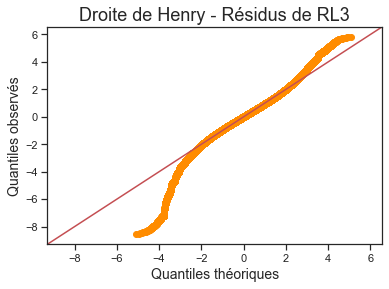

```python
residus_henry(RL3, "RL3", "darkorange")
plt.savefig("data/projet_7/graphiques/m4_35_henry_RL3.png")
plt.show()
```

Les résidus semblent bien suivrent une loi gaussienne selon la droite de Henry, excepté encore une fois pour quelques individus à faible résidus. On remarquera une adéquation à la loi normale encore meilleure que pour RL2. Analysont maintenant l'homoscédasticité de RL3 avec le nuage de variance résiduelle.

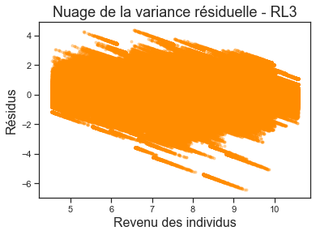

```python
nuage_residuel(RL3, "RL3", "darkorange")
plt.savefig("data/projet_7/graphiques/m4_35_nuage_RL3.png")
plt.show()
```

Les variances des résidus sont significativement égales selon ce nuage, on en déduit l'homoscédasticité de RL3 et attestons ainsi, de par ce résultat et les précédents, de la fiabilité du modèle de régression linéaire RL3.

### III.6. Ajout des variables restantes

Nous allons maintenant vérifier si d'autres variables présentes dans nos données de base influent sur la variance des revenus des individus.

```python
RL4=ols("log_y_child ~ log_mj+gini+c_i_parents+log_y_parents+elasticity+population", data=individus).fit(alpha=nt)
print(RL4.summary())
print("")
print("")
print("CE NOUVEAU MODELE EXPLIQUE ENVIRON", round(100*RL4.rsquared, 2), "% DE LA VARIANCE DE log_y_child")
```

```
                            OLS Regression Results
==============================================================================
Dep. Variable:            log_y_child   R-squared:                       0.784
Model:                            OLS   Adj. R-squared:                  0.784
Method:                 Least Squares   F-statistic:                 3.513e+06
Date:                Sun, 16 Aug 2020   Prob (F-statistic):               0.00
Time:                        12:22:08   Log-Likelihood:            -5.6554e+06
No. Observations:             5800000   AIC:                         1.131e+07
Df Residuals:                 5799993   BIC:                         1.131e+07
Df Model:                           6
Covariance Type:            nonrobust
=================================================================================
                    coef    std err          t      P>|t|      [0.025      0.975]
---------------------------------------------------------------------------------
Intercept         0.5699      0.003    203.668      0.000       0.564       0.575
log_mj            0.1446      0.001    267.341      0.000       0.144       0.146
gini             -0.2101      0.004    -58.793      0.000      -0.217      -0.203
c_i_parents      -0.0083    1.6e-05   -517.208      0.000      -0.008      -0.008
log_y_parents     0.8308      0.001   1462.680      0.000       0.830       0.832
elasticity       -0.0366      0.002    -22.292      0.000      -0.040      -0.033
population    -4.533e-11    1.6e-12    -28.275      0.000   -4.85e-11   -4.22e-11
==============================================================================
Omnibus:                   362879.796   Durbin-Watson:                   0.078
Prob(Omnibus):                  0.000   Jarque-Bera (JB):          1706800.461
Skew:                          -0.025   Prob(JB):                         0.00
Kurtosis:                       5.657   Cond. No.                     2.57e+09
==============================================================================

Warnings:
[1] Standard Errors assume that the covariance matrix of the errors is correctly specified.
[2] The condition number is large, 2.57e+09. This might indicate that there are
strong multicollinearity or other numerical problems.


CE NOUVEAU MODELE EXPLIQUE ENVIRON 78.42 % DE LA VARIANCE DE log_y_child
```

La pvalue de chaque variable étant égale à 0, elles semblent alors toutes significatives pour le modèle, et ce nouveau modèle explique environ **78,42%** de la variance des revenus, soit 8,12% de plus que RL3. Avant d'analyser la décomposition des variables, vérifions d'abord leurs éventuelles colinéarités.

```python
VIF(RL4, ["log_mj", "gini", "c_i_parents", "log_y_parents", "elasticity", "population"])
```

|  | VIF de la variable |
| --- | --- |
| log_mj | 6.283868 |
| gini | 1.438371 |
| c_i_parents | 3.002115 |
| log_y_parents | 8.668267 |
| elasticity | 1.515660 |
| population | 1.023082 |

```python
decomposition_des_variables(RL4)
```

|  | Pourcentage de l'explication de la variance |
| --- | --- |
| log_mj | 64.33 |
| gini | 0.85 |
| c_i_parents | 5.12 |
| log_y_parents | 8.11 |
| elasticity | 0.00 |
| population | 0.00 |
| Residual | 21.58 |

Il est intéressant de noter que le revenu même des parents vient s'ajouter à l'explication de la variance des revenus, avec un score de 8,12% dans notre dernier modèle, et que nous pouvons mettre de côté les variables "population" et "elasticity" selon ce modèle. On peut donc reconsidérer RL4 sans ces deux dernières variables.

```python
RL4=ols("log_y_child ~ log_mj+gini+c_i_parents+log_y_parents", data=individus).fit(alpha=nt)
print("Et ce modèle explique toujours", round(100*RL4.rsquared, 2), "% de la variance des revenus.")
```

```
Et ce modèle explique toujours 78.42 % de la variance des revenus.
```

```python
decomposition_des_variables(RL4)
```

|  | Pourcentage de l'explication de la variance |
| --- | --- |
| log_mj | 64.33 |
| gini | 0.85 |
| c_i_parents | 5.12 |
| log_y_parents | 8.11 |
| Residual | 21.58 |

Analysons les résidus pour nous assurer de la validité de cette dernière régression linéaire multiple.

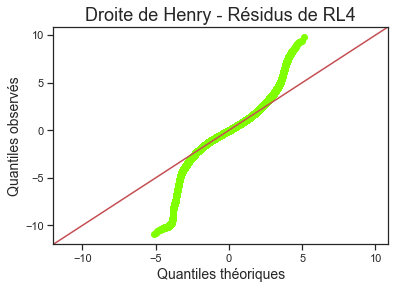

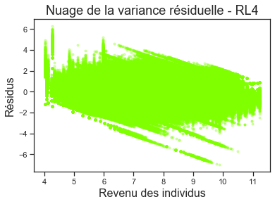

```python
#Droite de Henry:
residus_henry(RL4, "RL4", "chartreuse")
plt.savefig("data/projet_7/graphiques/m4_36_henry_RL4.png")
plt.show()

#Nuage de la variance résiduelle:
nuage_residuel(RL4, "RL4", "chartreuse")
plt.savefig("data/projet_7/graphiques/m4_36_nuage_RL4.png")
plt.show()
```

Les résidus semblent moins confondues avec la droite de Henry mais présentent tout de même une distribution sensiblement proche de la loi gaussienne, et les variances restent sensiblement proches sur le nuage pour ce qui est de l'homoscédasticité. On considérera alors ce dernier modèle comme étant fiable et nous nous reposerons dessus pour la conclusion.

# IV. Bilan sur la variance des revenus

### IV.1. Explication de la variance des revenus selon nos résultats

En se basant sur notre dernière régression linéaire, on établi ci-dessous la liste descendante des variables explicant la variance des revenus des individus selon leur pourcentage de contribution.

```python
decomposition_des_variables(RL4).head(4).sort_values(by="Pourcentage de l'explication de la variance", ascending=False)
```

|  | Pourcentage de l'explication de la variance |
| --- | --- |
| log_mj | 64.33 |
| log_y_parents | 8.11 |
| c_i_parents | 5.12 |
| gini | 0.85 |

Et nous avons vu que ce modèle explique environ **78,42%** de cette variance, ce qui signifie qu'environ 21,58% de cette variance s'explique par des facteurs extérieurs (efforts, chances, etc...).

### IV.3. Bonus: Proposition d'un algorithme de prédiction de revenus

Dans le scénario du projet, nous travaillons dans une banque où l'on a accès à chacune des quatre variables explicatives définies pour chacun de nos clients: le revenu moyen du pays où ils habitent, leur revenu, leur classe de revenu au sein de leur pays, et l'indice de Gini de leur pays. Voici donc un algorithme qui repose sur notre base de données qui, pour un client donné, prendrait en argument le revenu moyen de son pays, son revenu, sa classe de revenu et l'indice de gini de son pays et qui nous renvoie une estimation du revenu de ses enfants.

```python
#On se base uniquement sur les 4 variables en vigueurs présentes dans notre base:
donnees=individus[["y_child", "mj", "y_parents", "c_i_parents", "gini"]]

#Algorithme préliminaire pour l'algorithme de prédiction:
def proche(x, L):
    K=(abs(x-L))
    a=min(K)
    dt=pd.concat([L, K], axis=1)
    dt.columns=["vari", "abso"]
    dt.drop_duplicates(inplace=True)
    i=list(dt.loc[dt["abso"]==a]["vari"])[0]
    return(i)


#Algorithme de prédiction:
def prediction(revenu_moyen_pays, revenu_parent, classe_parent, gini):

    rmp=proche(revenu_moyen_pays, donnees["mj"])
    data=donnees.loc[donnees["mj"]==rmp]

    rp=proche(revenu_parent, data["y_parents"])
    data=data.loc[data["y_parents"]==rp]

    cp=proche(classe_parent, data["c_i_parents"])
    data=data.loc[data["c_i_parents"]==cp]

    g=proche(gini, data["gini"])
    data=data.loc[data["gini"]==g]

    return(round(data["y_child"].mean(), 2))
```

```python
prediction(2500, 3000, 60, 0.35)
```

```
3123.56
```